# Testing the wind disruption and disturbance refugia hypothesis for mountain pine beetle outbreaks (*Dendroctonus ponderosae*)

```r
if (!file.exists(here::here("02.inputs/beetle/covariates/wind_direction_pooled.txt"))) {

## Prevailing wind direction in the beetle flight window.
##
## Needed because the geomorphometric wind indices are directional. SAGA's windward /
## leeward index and its wind shelter index both ask which way the wind comes from, and
## answering "we do not know, so average all eight bearings" throws away the one thing
## terrain-driven wind has that a gridded climatology does not.
##
## Direction is taken from the same ECCC hourly records 30-wind-hourly-metrics.R uses,
## over the same flight window, 1 July to 15 August. `wind_dir` is reported in tens of
## degrees, so it is multiplied by 10. Directions are averaged as unit vectors, never
## arithmetically: the mean of 350 and 10 degrees is 0, not 180.
##
## The convention that matters downstream: ECCC reports the direction the wind comes
## FROM. SAGA's DIR_CONST expects the same. No conversion is applied and this comment
## is the record that none was needed.

suppressPackageStartupMessages({library(weathercan); library(sf); library(terra); library(dplyr)})
ROOT <- here::here("02.inputs", "beetle")
OUT  <- file.path(ROOT, "covariates"); dir.create(OUT, recursive = TRUE, showWarnings = FALSE)
YEARS <- c(2005:2011, 2013, 2014)

g   <- rast(file.path(ROOT, "ndmi-darkwoods", "analysis_grid.tif"))
ctr <- st_transform(st_sfc(st_point(c(mean(ext(g)[1:2]), mean(ext(g)[3:4]))), crs = 32611), 4326)
cc  <- st_coordinates(ctr)
sl  <- weathercan::stations_search(coords = c(cc[2], cc[1]), interval = "hour", dist = 150)
sl  <- sl[!is.na(sl$start) & sl$start <= 2014 & !is.na(sl$end) & sl$end >= 2005, ]
ids <- unique(sl$station_id)
cat(sprintf("hourly stations within 150 km: %d\n", length(ids)))

rows <- list()
for (y in YEARS) {
  w <- try(weathercan::weather_dl(station_ids = ids, interval = "hour",
             start = sprintf("%d-07-01", y), end = sprintf("%d-08-15", y)), silent = TRUE)
  if (inherits(w, "try-error")) { cat("no data", y, "\n"); next }
  d <- w |> filter(!is.na(wind_dir), !is.na(wind_spd), wind_spd > 0) |>
            mutate(deg = wind_dir * 10, rad = deg * pi/180)
  if (!nrow(d)) next
  ## Speed-weighted resultant, so the bearing reported is the one that carries the air,
  ## not the one that occurs most often at a dead calm.
  u <- sum(d$wind_spd * sin(d$rad)); v <- sum(d$wind_spd * cos(d$rad))
  bear <- (atan2(u, v) * 180/pi) %% 360
  R <- sqrt(u^2 + v^2) / sum(d$wind_spd)          # 0 = no prevailing direction, 1 = constant
  rows[[length(rows)+1]] <- data.frame(year = y, n_hours = nrow(d),
    n_stations = length(unique(d$station_id)), prevailing_deg = round(bear, 1),
    consistency = round(R, 3), mean_spd = round(mean(d$wind_spd), 2))
  cat(sprintf("%d  n=%5d  from %5.1f deg  R=%.3f\n", y, nrow(d), bear, R))
}
wd <- do.call(rbind, rows)

## Pooled bearing across all years, which is what a static terrain index needs.
u <- sum(wd$n_hours * sin(wd$prevailing_deg * pi/180))
v <- sum(wd$n_hours * cos(wd$prevailing_deg * pi/180))
pooled <- (atan2(u, v) * 180/pi) %% 360
attr(wd, "pooled") <- pooled
write.csv(wd, file.path(OUT, "wind_direction_flight_window.csv"), row.names = FALSE)
writeLines(sprintf("%.1f", pooled), file.path(OUT, "wind_direction_pooled.txt"))
cat(sprintf("\npooled prevailing direction, flight window: %.1f degrees (from)\n", pooled))
cat(sprintf("between-year spread: %.1f to %.1f degrees\n",
            min(wd$prevailing_deg), max(wd$prevailing_deg)))
}
```

```r
if (!file.exists(here::here("02.inputs/beetle/geomorphometry/geomorphometry.tif"))) {

## Geomorphometry, and the terrain-driven wind field.
##
## Why this replaces the interpolated station surface as the spatial wind term. Wind
## over this site is made by the terrain: a 914 m relief ridge system decides where air
## accelerates, separates and stalls. Interpolating four to seven valley stations across
## 150 km cannot see any of that, and did not: the 2009 surface spanned 7.27 to 7.79 km/h
## across 50 km. The station records keep the temporal signal, at hourly resolution and
## in the flight window; the spatial signal has to come from the shape of the ground.
##
## The parent study licenses the terrain half directly. Its point-process model of
## post-outbreak conifer regeneration returns terrain ruggedness at beta = 1.3563 with an
## LR-test p of 0.001, alongside aspect, slope, TWI and a wind term at beta = -0.0662,
## p = 0.002 (Murphy et al. 2026, Table 4). Ruggedness is the strongest terrain effect it
## reports, so a study on the same landscape that omitted terrain shape would be ignoring
## its own parent's result.
##
## Everything runs at 30 m in EPSG:3153 on the DEM from 33-study-perimeter.R. Indices are
## computed over the full reprojected DEM and only then clipped to the perimeter, so a
## search radius near the boundary sees real ground rather than NA.
##
## Directional indices use the prevailing flight-window bearing from
## 36-wind-direction.R, 258.2 degrees, speed-weighted over 1 July to 15 August. That
## bearing is weakly constrained: the resultant length is about 0.19 and the between-year
## spread runs 224.5 to 293.4 degrees. The omnidirectional indices are carried alongside
## for exactly that reason, and the variable-selection stage is allowed to choose.

suppressPackageStartupMessages({library(sf); library(terra)})
ROOT  <- here::here("02.inputs", "beetle")
SA    <- file.path(ROOT, "study-area")
OUT   <- file.path(ROOT, "geomorphometry"); dir.create(OUT, showWarnings = FALSE)
## A persistent working directory, not tempdir(): SAGA writes each grid as three files
## and a truncated .sdat reads back as a GDAL block error rather than as a failure, so
## the intermediates have to survive the session to be inspected.
TMP   <- file.path(ROOT, "geomorphometry", "saga"); dir.create(TMP, recursive = TRUE, showWarnings = FALSE)
SAGA  <- "/opt/local/bin/saga_cmd"
DATA  <- Sys.getenv("DARKWOODS_DATA",
  "/Users/seamus/repos/publications-pending/Darkwoods-Disturbance-Paper/3.SpatialData")
DIR   <- as.numeric(readLines(file.path(ROOT, "covariates", "wind_direction_pooled.txt")))

## Full DEM, not the clipped one: the clip happens after every index is computed.
dem <- project(rast(file.path(DATA, "terrain_environment", "Elevation.utm.tif")),
               "EPSG:3153", res = 30, method = "bilinear")
names(dem) <- "elevation"
tif <- file.path(TMP, "dem.tif"); writeRaster(dem, tif, overwrite = TRUE)
sg  <- file.path(TMP, "dem.sgrd")
system2(SAGA, c("io_gdal", "0", "-FILES", tif, "-GRIDS", sg), stdout = FALSE, stderr = FALSE)
stopifnot(file.exists(sg))
cat(sprintf("DEM %d x %d at 30 m, %.0f-%.0f m, prevailing wind from %.1f degrees\n",
            nrow(dem), ncol(dem), minmax(dem)[1], minmax(dem)[2], DIR))

o <- function(n) file.path(TMP, paste0(n, ".sgrd"))

## SAGA writes the insolation unit as "kWh/m^2" using a superscript two, and that single
## non-ASCII byte runs the UNIT line into the next one, so the header reads
## `UNIT = kWh/m^2DATAFORMAT = FLOAT` with no line break. GDAL then cannot find
## DATAFORMAT, and reading the grid fails with "Unable to read block from grid file"
## even though the .sdat is the right size and entirely correct. The header is repaired
## before the grid is read. This affects only the two ta_lighting 2 outputs, and it is
## silent: the tool reports success.
fix_sgrd <- function(n) {
  f <- file.path(TMP, paste0(n, ".sgrd"))
  if (!file.exists(f)) return(invisible(FALSE))
  h <- readLines(f, warn = FALSE)
  bad <- grepl("DATAFORMAT", h, fixed = TRUE) & grepl("UNIT", h, fixed = TRUE)
  if (!any(bad)) return(invisible(TRUE))
  ## Split the run-together line at DATAFORMAT, then drop the UNIT line entirely. UNIT
  ## is an optional descriptive field; DATAFORMAT is not, and losing it is what breaks
  ## the read. Substitutions are fixed = TRUE so no escaping is involved.
  h <- unlist(lapply(h, function(x)
    if (grepl("DATAFORMAT", x, fixed = TRUE) && grepl("UNIT", x, fixed = TRUE))
      strsplit(sub("DATAFORMAT", "\nDATAFORMAT", x, fixed = TRUE), "\n", fixed = TRUE)[[1]]
    else x))
  h <- h[!startsWith(h, "UNIT")]
  writeLines(h, f)
  cat("  repaired header:", n, "\n")
  invisible(TRUE)
}

run <- function(lib, id, ...) {
  a <- c(lib, as.character(id), unlist(list(...)))
  r <- system2(SAGA, a, stdout = FALSE, stderr = FALSE)
  cat(sprintf("  %-18s %-3s %s\n", lib, id, ifelse(r == 0, "ok", paste("FAILED", r))))
  invisible(r)
}

## ---- wind, from the shape of the ground -------------------------------------------
## Windward/leeward index and effective air flow height at the prevailing bearing.
run("ta_morphometry", 15, "-DEM", sg, "-EFFECT", o("wind_effect"),
    "-AFH", o("wind_afh"), "-DIR_CONST", DIR, "-DIR_UNITS", 1, "-MAXDIST", 300)
## Omnidirectional exposition, 300 m search: how open a cell is to wind from anywhere.
run("ta_morphometry", 27, "-DEM", sg, "-EXPOSITION", o("wind_exposition"),
    "-MAXDIST", 0.3, "-STEP", 15)
## Winstral-style shelter: maximum upwind slope angle, at the prevailing bearing.
## Tool 29 takes -ELEVATION, not -DEM, and its -DISTANCE is in cells: 17 cells is
## 510 m, matching the 500 m radius used for openness and sky view.
run("ta_morphometry", 29, "-ELEVATION", sg, "-SHELTER", o("wind_shelter"),
    "-DIRECTION", DIR, "-UNIT", 0, "-DISTANCE", 17, "-TOLERANCE", 10)
## Openness and sky view, the two scale-free measures of exposure versus enclosure.
run("ta_lighting", 5, "-DEM", sg, "-POS", o("openness_pos"), "-NEG", o("openness_neg"),
    "-RADIUS", 500)
run("ta_lighting", 3, "-DEM", sg, "-VISIBLE", o("sky_view"), "-RADIUS", 500)
```

```r
## ---- ruggedness and shape, the parent's RIX and its relatives ----------------------
run("ta_morphometry", 16, "-DEM", sg, "-TRI", o("tri"), "-RADIUS", 1)
run("ta_morphometry", 17, "-DEM", sg, "-VRM", o("vrm"), "-RADIUS", 1)
run("ta_morphometry", 18, "-DEM", sg, "-TPI", o("tpi"), "-RADIUS_MAX", 300)
run("ta_morphometry", 28, "-DEM", sg, "-TPI", o("mstpi"), "-SCALE_MIN", 1,
    "-SCALE_MAX", 8, "-SCALE_NUM", 3)
run("ta_morphometry", 1, "-ELEVATION", sg, "-RESULT", o("convergence"))
run("ta_morphometry", 0, "-ELEVATION", sg, "-SLOPE", o("slope"), "-ASPECT", o("aspect"),
    "-C_PROF", o("curv_prof"), "-C_PLAN", o("curv_plan"), "-UNIT_SLOPE", 1, "-UNIT_ASPECT", 1)
run("ta_lighting", 8, "-DEM", sg, "-GEOMORPHONS", o("geomorphons"), "-THRESHOLD", 1,
    "-RADIUS", 300)

## ---- energy: the radiation the biology actually names -----------------------------
## Three separate claims in the literature make solar radiation a first-order terrain
## variable here rather than a control.
##
## (1) Krawchuk et al. (2020) name topographic shading as their FIRST refugia mechanism
##     for mountain pine beetle: refugia could occur "in areas with cooler temperatures
##     (eg from topographic shading) that protect trees from water stress ... and more
##     vigorous tree growth and chemical defenses". Shading is a radiation quantity.
## (2) Flight is thermally gated. Safranyik and Wilson (2006) give "the estimated lower
##     and upper temperature limits for beetle flight are 19 and 41 degrees C
##     (McCambridge 1971), most beetles fly when temperatures are between 22 and 32
##     degrees C (Safranyik 1978)", and "Most beetles emerge when temperatures are above
##     20 degrees C". A slope that does not reach 19 degrees C in the flight window is
##     unreachable by flight whatever else is true of it.
## (3) The timing is specific: "most flights occur on bright sunny days, and peak flight
##     is in the early to mid afternoon (Reid 1960)".
##
## So radiation is computed twice, for two different mechanisms, rather than as one
## annual number. FLIGHT is direct and diffuse insolation over 1 July to 15 August
## restricted to 12:00-17:00, the hours the flight peak occupies. SEASON is the
## growing-season total, 1 May to 30 September over the whole day, which is the
## radiation load a tree experiences and therefore Krawchuk's water-stress pathway.
## A static heat-load index cannot separate those two, which is why it is not enough.
LAT <- mean(as.vector(ext(project(dem, "EPSG:4326")))[3:4])
run("ta_lighting", 2, "-GRD_DEM", sg, "-GRD_DIRECT", o("solar_flight_direct"),
    "-GRD_DIFFUS", o("solar_flight_diffuse"),
    "-LOCATION", 0, "-LATITUDE", LAT, "-PERIOD", 2, "-UNITS", 0,
    "-DAY", "2009-07-01", "-DAY_STOP", "2009-08-15", "-DAYS_STEP", 3,
    "-HOUR_RANGE_MIN", 12, "-HOUR_RANGE_MAX", 17, "-HOUR_STEP", 1, "-SHADOW", 1)
run("ta_lighting", 2, "-GRD_DEM", sg, "-GRD_DIRECT", o("solar_season_direct"),
    "-GRD_TOTAL", o("solar_season_total"),
    "-LOCATION", 0, "-LATITUDE", LAT, "-PERIOD", 2, "-UNITS", 0,
    "-DAY", "2009-05-01", "-DAY_STOP", "2009-09-30", "-DAYS_STEP", 7,
    "-HOUR_RANGE_MIN", 4, "-HOUR_RANGE_MAX", 21, "-HOUR_STEP", 1, "-SHADOW", 1)

## ---- cold air, snow and the places infestation is reported to gather ----------------
## Two more statements from the same synthesis put specific landforms in the model.
## "Thick bark and deep snow will insulate beetle broods from declining ambient
## temperatures", so where cold air pools and snow lies is where broods survive winter.
## And "groups of infested trees are frequently associated with draws and gullies, edges
## of swamps or other places with wide fluctuation in the water table". Draws and gullies
## are convergent terrain, which the convergence index and topographic wetness measure,
## and relative slope position separates a valley floor from a mid-slope bench.
run("ta_morphometry", 14, "-DEM", sg, "-HO", o("height_slope_top"),
    "-HU", o("height_valley_floor"), "-NH", o("normalised_height"),
    "-SH", o("standardised_height"), "-MS", o("midslope_position"))

## ---- moisture, and the alternative explanations that must be controlled ------------
run("ta_hydrology", 15, "-DEM", sg, "-TWI", o("twi"))
## Potential annual insolation writes a grid collection rather than a grid, so the
## energy term is the McCune and Keon (2002) heat load index instead, computed below
## from slope, aspect and latitude. It is the same quantity the earlier draft used.
run("ta_channels", 7, "-ELEVATION", sg, "-VALLEY_DEPTH", o("valley_depth"))

## ---- collect ----------------------------------------------------------------------
for (n in c("solar_flight_direct","solar_flight_diffuse",
            "solar_season_direct","solar_season_total")) fix_sgrd(n)

LAY <- c("wind_effect","wind_afh","wind_exposition","wind_shelter","openness_pos",
         "openness_neg","sky_view","tri","vrm","tpi","mstpi","convergence","slope",
         "aspect","curv_prof","curv_plan","geomorphons","twi","valley_depth",
         "solar_flight_direct","solar_flight_diffuse",
         "solar_season_direct","solar_season_total",
         "height_valley_floor","normalised_height","midslope_position")
msk <- rast(file.path(SA, "perimeter_mask.tif"))
got <- character(0); st <- list()
for (n in LAY) {
  f <- file.path(TMP, paste0(n, ".sdat"))
  if (!file.exists(f)) { cat("  missing:", n, "\n"); next }
  r <- rast(f); crs(r) <- "EPSG:3153"; names(r) <- n
  st[[n]] <- mask(crop(r, msk), msk); got <- c(got, n)
}
s <- rast(st)
## Aspect is circular and unusable as a linear predictor; it enters as its components.
if ("aspect" %in% got) {
  a <- s[["aspect"]] * pi/180
  s <- c(s, setNames(cos(a), "northness"), setNames(sin(a), "eastness"))
  ## Heat load after McCune and Keon (2002) equation 3: aspect folded about the
  ## southwest-northeast axis so southwest is hottest, which is the axis that matters
  ## here because the confound this study cannot resolve is wind exposure against cold.
  lat <- mean(as.vector(ext(project(s[["aspect"]], "EPSG:4326")))[3:4]) * pi/180
  sl  <- s[["slope"]] * pi/180
  af  <- abs(pi - abs(a - (5*pi/4)))
  hl  <- exp(-1.467 + 1.582*cos(lat)*cos(sl) - 1.500*cos(af)*sin(sl)*sin(lat)
             - 0.262*sin(lat)*sin(sl) + 0.607*sin(af)*sin(sl))
  s <- c(s, setNames(hl, "heat_load"))
}
writeRaster(s, file.path(OUT, "geomorphometry.tif"), overwrite = TRUE,
            datatype = "FLT4S", gdal = c("COMPRESS=DEFLATE"))
cat(sprintf("\nwrote %d layers over %d cells\n", nlyr(s), sum(!is.na(values(msk)))))
d <- as.data.frame(s, na.rm = FALSE)
print(round(t(sapply(d, function(x) c(min = min(x, na.rm = TRUE),
      median = stats::median(x, na.rm = TRUE), max = max(x, na.rm = TRUE),
      pct_na = 100*mean(is.na(x))))), 3))
}
```

```r
if (!file.exists(here::here("02.inputs/beetle/study-area/vri_context.tif"))) {

## Unclipped covariate surfaces, for the manuscript's figures only.
##
## Why this exists. Every covariate raster the models use is masked to the study
## perimeter, and that perimeter is the burn buffered 5 km then cut to the 830 to 1744 m
## elevation band. Drawn on their own the surfaces are a ring with a hole in it, floating
## on a base map, and a reader cannot tell a study boundary from a clipping error.
##
## These surfaces fill the map instead. They are the SAME computations, not different
## ones: 37-geomorphometry.R computes every index over the full reprojected DEM and only
## clips when it assembles the stack, so its SAGA intermediates in geomorphometry/saga/
## are already unclipped and are simply read back here. The inventory is re-rasterised
## from the same polygons over the wider page.
##
## THESE ARE FOR DISPLAY ONLY. No model reads them. The study perimeter is drawn over
## them in every figure, so the ground the analysis excludes is visible as excluded.
##
## Writes:
##   study-area/geomorphometry_context.tif
##   study-area/vri_context.tif
##
## Run:  /usr/local/bin/Rscript 02.inputs/beetle/49-context-covariates.R

suppressPackageStartupMessages({library(sf); library(terra)})

ROOT <- here::here("02.inputs", "beetle")
SA   <- file.path(ROOT, "study-area")
TMP  <- file.path(ROOT, "geomorphometry", "saga")

## The page, from the same two constants the maps use: 1:250,000 at a 66 mm panel is
## 16.5 km of ground. Keep in step with MAP_RF and MAP_PANEL in
## 01.manuscript/_shared/map-academic.R and with 48-fetch-basemap-relief.R.
RF <- 150000; PANEL_MM <- 66
W  <- RF * PANEL_MM / 1000  # 9,900 m
ASPECT <- 1.45

per <- st_read(file.path(SA, "study_perimeter.gpkg"), quiet = TRUE) |> st_transform(3153)
ctr <- as.numeric(st_coordinates(st_centroid(st_union(per))))
page <- ext(c(ctr[1] - W/2, ctr[1] + W/2, ctr[2] - W*ASPECT/2, ctr[2] + W*ASPECT/2))
grid <- rast(page, resolution = 30, crs = "EPSG:3153")
cat(sprintf("page %.2f x %.2f km at 30 m, %d x %d cells\n",
            W/1000, W*ASPECT/1000, nrow(grid), ncol(grid)))

## ---- terrain, read back unclipped from the SAGA intermediates ---------------------
WANT <- c("wind_effect", "tri", "vrm", "tpi", "twi", "valley_depth", "convergence",
          "curv_prof", "midslope_position", "height_valley_floor", "normalised_height",
          "northness", "eastness", "heat_load", "slope", "aspect",
          "solar_flight_direct", "solar_season_direct", "geomorphons")
got <- list()
for (n in WANT) {
  f <- file.path(TMP, paste0(n, ".sdat"))
  if (!file.exists(f)) { cat("  missing:", n, "\n"); next }
  r <- rast(f); crs(r) <- "EPSG:3153"
  got[[n]] <- resample(crop(r, page, extend = TRUE), grid,
                       method = if (n == "geomorphons") "near" else "bilinear")
}
## northness and eastness are derived from aspect in 37-, not written by SAGA, so they
## are derived the same way here rather than silently dropped.
if (!is.null(got$aspect)) {
  got$northness <- cos(got$aspect); got$eastness <- sin(got$aspect)
}
geo <- rast(got[!vapply(got, is.null, logical(1))])
names(geo) <- names(got)[!vapply(got, is.null, logical(1))]
cat(sprintf("terrain: %d layers, non-NA %.1f%%\n", nlyr(geo),
            100 * mean(!is.na(values(geo[[1]])))))
writeRaster(geo, file.path(SA, "geomorphometry_context.tif"), overwrite = TRUE,
            gdal = c("COMPRESS=DEFLATE", "PREDICTOR=2"))

## ---- inventory, re-rasterised over the wider page ---------------------------------
## vri_page.geojson, not vri_perimeter.geojson: the perimeter extract was fetched over
## the perimeter's own bounding box and covers only 30 per cent of the map page, so a
## panel drawn from it still looked clipped. This is the same layer and the same fields
## over the page bbox, 2,991 polygons against 1,084.
v <- st_read(file.path(SA, "vri_page.geojson"), quiet = TRUE) |> st_transform(3153)
FIELDS <- c("BASAL_AREA", "CROWN_CLOSURE", "VRI_LIVE_STEMS_PER_HA", "QUAD_DIAM_125",
            "PROJ_AGE_1", "PROJ_HEIGHT_1", "LIVE_STAND_VOLUME_125")
FIELDS <- FIELDS[FIELDS %in% names(v)]
## terra::vect() converts an INTEGER column's NA to the INT32 minimum, -2147483648, and
## rasterize then carries that through as a value: the colour ramp runs from zero to minus
## two billion and the panel is unreadable. It hits CROWN_CLOSURE, VRI_LIVE_STEMS_PER_HA
## and PROJ_AGE_1, the three integer fields, and leaves the four double fields alone,
## which is why it showed on three panels and not seven. The cast to double is the fix;
## a guard afterwards is not, because by then the sentinel is indistinguishable from data.
for (f in FIELDS) v[[f]] <- as.numeric(v[[f]])

vri <- rast(lapply(FIELDS, function(f) rasterize(vect(v), grid, field = f)))
names(vri) <- FIELDS

## Ground the inventory does not map carries no stand, and on a figure that reads as a
## hole punched through the colour ramp. For DISPLAY the unmapped cells are set to zero
## so the ramp runs continuously from zero, which is what those cells mean: no stand, no
## basal area, no stems. This is a cartographic choice and it is confined to this file.
## The modelled rasters keep their NAs, and every model drops those rows explicitly
## rather than letting glm do it silently.
vri <- classify(vri, cbind(NA, 0))
cat(sprintf("unmapped cells set to zero for display; non-NA now %.1f%%\n",
            100 * mean(!is.na(values(vri[[1]])))))
cat(sprintf("inventory: %d layers from %d polygons, non-NA %.1f%%\n",
            nlyr(vri), nrow(v), 100 * mean(!is.na(values(vri[[1]])))))
writeRaster(vri, file.path(SA, "vri_context.tif"), overwrite = TRUE,
            gdal = c("COMPRESS=DEFLATE", "PREDICTOR=2"))

## ---- MicroMet wind weighting over the page ----------------------------------------
## The stored surface is masked to the perimeter, so a panel drawn from it is the only
## one on the figure with a hole in it. Equations 14 to 16 of Liston and Elder (2006) are
## re-applied here over the context DEM, with the same gamma_s = gamma_c = 0.5 and the
## same curvature length scale, so this is the same quantity as 41-micromet-wind.R
## computes, over more ground.
GS <- GC <- 0.5
ETA_M <- 600                                   # curvature length scale, from 41-
DIR <- as.numeric(readLines(file.path(ROOT, "covariates", "wind_direction_pooled.txt")))
dem <- resample(rast(file.path(SA, "dem_context.tif")), grid)
eta <- max(1, round(ETA_M / res(grid)[1]))

sh <- function(dx, dy) shift(dem, dx * res(grid)[1], dy * res(grid)[2])
z <- dem
oc <- 0.25 * ((z - 0.5 * (resample(sh(-eta, 0), grid) + resample(sh(eta, 0), grid))) / (2 * ETA_M) +
              (z - 0.5 * (resample(sh(0, -eta), grid) + resample(sh(0, eta), grid))) / (2 * ETA_M) +
              (z - 0.5 * (resample(sh(-eta, -eta), grid) + resample(sh(eta, eta), grid))) / (2 * sqrt(2) * ETA_M) +
              (z - 0.5 * (resample(sh(-eta, eta), grid) + resample(sh(eta, -eta), grid))) / (2 * sqrt(2) * ETA_M))
scale01 <- function(r) { m <- max(abs(as.vector(minmax(r))), na.rm = TRUE); r / (2 * m) }
OC <- scale01(oc)
beta <- terrain(dem, "slope",  unit = "radians")
xi   <- terrain(dem, "aspect", unit = "radians")
th   <- DIR * pi / 180
OS   <- scale01(beta * cos(th - xi))
Ww   <- 1 + GS * OS + GC * OC
## shift() drops a border one curvature length scale wide, so the surface stops short of
## the frame and the panel reads as clipped again. Fill that border from the nearest
## computed cell: it is a cartographic edge treatment on a display raster, not an
## extrapolation anything is fitted to.
Ww   <- focal(Ww, w = 9, fun = mean, na.policy = "only", na.rm = TRUE)
Ww   <- focal(Ww, w = 25, fun = mean, na.policy = "only", na.rm = TRUE)
names(Ww) <- "mm_weight"
cat(sprintf("MicroMet weighting over the page: %.3f to %.3f (paper bounds 0.5 to 1.5)\n",
            minmax(Ww)[1], minmax(Ww)[2]))
writeRaster(Ww, file.path(SA, "micromet_weight_context.tif"), overwrite = TRUE,
            gdal = c("COMPRESS=DEFLATE", "PREDICTOR=2"))

cat("wrote geomorphometry_context.tif, vri_context.tif and micromet_weight_context.tif (display only)\n")
}
```

```r
if (!file.exists(here::here("02.inputs/beetle/study-area/vri-timeseries/vri_2014.gpkg"))) {

## The annual Vegetation Resources Inventory, one snapshot per study year.
##
## Why this exists. Until 2026-08-28 the stand structure came from the live WFS layer
## WHSE_FOREST_VEGETATION.VEG_COMP_LYR_R1_POLY, which is a single composite projected to
## 2025. Every annual observation of a cell therefore carried the SAME basal area, volume,
## stems and diameter, so the host terms had no time variation at all, and the attributes
## had been grown forward through and past the outbreak they were meant to predict. On the
## study perimeter that layer gives a mean basal area of 35.18 m2/ha; the annualized 2014
## snapshot gives 30.0, with 787 stems per hectare against 670 and a quadratic mean
## diameter of 26.74 cm against 30.13.
##
## The province publishes the correct thing: VRI - HISTORICAL Vegetation Resource
## Inventory (2002 - 2024), catalogue id 02dba161-fdb7-48ae-a4bb-bd6ef017c36d, one File
## Geodatabase per year, "updated for depletions, such as harvesting, and projected
## annually for growth". Each year's PROJECTED_DATE is 31 December of the year before its
## label, so the 2014 file is the stand as it stood entering 2014.
##
## Two things make this practical. The archives are about 3.9 GB each, so downloading all
## nine would be 35 GB; GDAL can instead read them in place over HTTP and pull only the
## byte ranges the spatial filter needs. But the server answers HEAD with 404, which
## breaks vsicurl's size probe and makes the dataset look unopenable, so
## CPL_VSIL_CURL_USE_HEAD=NO is required and is not optional.
##
## Writes: study-area/vri-timeseries/vri_<year>.gpkg, clipped to the map page in EPSG:3153
##
## Run:  /usr/local/bin/Rscript 02.inputs/beetle/50-fetch-vri-timeseries.R

suppressPackageStartupMessages({library(sf); library(terra)})

ROOT <- here::here("02.inputs", "beetle")
SA   <- file.path(ROOT, "study-area")
OUT  <- file.path(SA, "vri-timeseries"); dir.create(OUT, showWarnings = FALSE)
BASE <- "https://pub.data.gov.bc.ca/datasets/02dba161-fdb7-48ae-a4bb-bd6ef017c36d"

## The study years. 2012 is absent by design: it is the one year covered only by Landsat 7
## with its scan-line corrector off, and it is excluded from the response as well.
YEARS <- c(2005:2011, 2013, 2014)

## Nothing about these archives is uniform, so nothing is guessed. Three things vary:
##   the zip's file name        VRI2005_..._FINAL_DELIVERYV4.gdb.zip up to 2006, then
##                              VEG_COMP_LYR_R1_POLY_<year>.gdb.zip
##   the folder inside the zip  usually matches the zip stem, but where it does not GDAL
##                              cannot descend into it and reports the whole archive as
##                              "not recognized as being in a supported file format",
##                              which reads as a corrupt download and is not one
##   the layer inside the gdb   VEG_COMP_LYR_R1_POLY from 2007, but
##                              VEG_COMP_LYR_R1_POLY_FINALV4 in 2005 and 2006
## The first is read from the directory listing, the other two from the archive itself.

GDALENV <- c("CPL_VSIL_CURL_USE_HEAD=NO", "GDAL_DISABLE_READDIR_ON_OPEN=EMPTY_DIR",
             "GDAL_HTTP_TIMEOUT=600")

zip_for <- function(y) {
  h <- readLines(url(sprintf("%s/%d/", BASE, y)), warn = FALSE)
  f <- unlist(regmatches(h, gregexpr('[A-Za-z0-9_]+\\.gdb\\.zip', h)))
  f <- unique(f[grepl("R1_POLY", f)])
  if (!length(f)) stop("no R1 polygon archive listed for ", y)
  f[1]
}

## Descend into the zip and name the .gdb explicitly, then ask OGR for its layer. None of
## the three is derivable from the year: the zip name changes after 2006, the folder inside
## it is VRI2006_..._V4.gdb in 2006 but lowercase veg_comp_lyr_r1_poly.gdb in 2009 and
## veg_comp_lyr_r1.gdb in 2011, and the layer is VEG_COMP_LYR_R1_POLY_FINALV4 before 2007.
##
## The listing is read with sf::gdal_utils("info") rather than by shelling out to Python,
## which is what failed for 2009 and 2011: the answer arrived on a line the caller was not
## reading and the year was reported as unresolvable when the archive was fine.
source_for <- function(y) {
  zf <- zip_for(y)
  z  <- sprintf("/vsizip//vsicurl/%s/%d/%s", BASE, y, zf)
  ## No listing API is used. Every inner-folder form the series has actually shown is
  ## tried against ogrinfo, plus the bare archive, and whichever opens is the source.
  ## Listing the zip was the fragile step: it worked for some years and returned nothing
  ## for 2009 and 2011, which were then reported as unresolvable although both open fine.
  stem <- sub("[.]gdb[.]zip$", "", zf)
  cands <- c(z,
             file.path(z, paste0(stem, ".gdb")),
             file.path(z, "VEG_COMP_LYR_R1_POLY.gdb"),
             file.path(z, "veg_comp_lyr_r1_poly.gdb"),
             file.path(z, "veg_comp_lyr_r1.gdb"),
             file.path(z, tolower(paste0(stem, ".gdb"))))
  for (src in unique(cands)) {
    info <- suppressWarnings(system2("ogrinfo", c("-ro", shQuote(src)), env = GDALENV,
                                     stdout = TRUE, stderr = TRUE))
    lyr <- grep("^Layer: ", info, value = TRUE)
    if (length(lyr)) {
      lyr <- trimws(sub("\\(.*$", "", sub("^Layer: ", "", lyr[1])))
      if (nzchar(lyr)) return(list(src = src, layer = lyr))
    }
  }
  stop("no readable layer for ", y)
}

## Field names are not stable across the series. 2007 and earlier use the older truncated
## schema, so the same attribute arrives under a different name and a naive extract silently
## returns a year with most of its columns missing. Standing volume is the one attribute
## with no single equivalent before 2008: it exists only per species, VOLSP1_125 through
## VOLSP6_125, which sum to it.
FIELD_MAP <- list(
  CROWN_CLOSURE         = c("CROWN_CLOSURE", "CR_CLOSURE"),
  VRI_LIVE_STEMS_PER_HA = c("VRI_LIVE_STEMS_PER_HA", "LIVE_STEMS"),
  QUAD_DIAM_125         = c("QUAD_DIAM_125", "Q_DIAM_125"),
  PROJ_HEIGHT_1         = c("PROJ_HEIGHT_1", "PROJ_HT_1"),
  SPECIES_CD_1          = c("SPECIES_CD_1", "SPEC_CD_1"),
  SPECIES_PCT_1         = c("SPECIES_PCT_1", "SPEC_PCT_1"),
  BASAL_AREA            = c("BASAL_AREA"),
  PROJ_AGE_1            = c("PROJ_AGE_1"),
  LIVE_STAND_VOLUME_125 = c("LIVE_STAND_VOLUME_125")
)
## Per-species volume carries three different names across the series: VOLSP1_125 in the
## 2007 and earlier schema, VOL_PER_HA_SPP1_125 in 2008, and a single
## LIVE_STAND_VOLUME_125 from 2009. All three are handled, because a year whose volume
## column is merely renamed is not a year with missing volume.
VOLSP <- c(sprintf("VOLSP%d_125", 1:6), sprintf("VOL_PER_HA_SPP%d_125", 1:6))

## Rename what the map covers, and rebuild standing volume from the per-species columns
## where the single column is absent. Returns the layer with the modern names.
harmonise <- function(v) {
  for (target in names(FIELD_MAP)) {
    if (target %in% names(v)) next
    alt <- FIELD_MAP[[target]][FIELD_MAP[[target]] %in% names(v)]
    if (length(alt)) names(v)[names(v) == alt[1]] <- target
  }
  if (!"LIVE_STAND_VOLUME_125" %in% names(v)) {
    have <- VOLSP[VOLSP %in% names(v)]
    if (length(have)) {
      m <- as.data.frame(sf::st_drop_geometry(v)[, have, drop = FALSE])
      m[] <- lapply(m, function(x) { x <- as.numeric(x); x[!is.finite(x)] <- 0; x })
      v$LIVE_STAND_VOLUME_125 <- rowSums(m)
      attr(v, "volume_from") <- paste(have, collapse = "+")
    }
  }
  v
}

g <- rast(file.path(SA, "geomorphometry_context.tif"))
e <- unname(as.vector(ext(g)))
cat(sprintf("clipping to the map page, EPSG:3153: %.0f %.0f %.0f %.0f\n",
            e[1], e[3], e[2], e[4]))

for (y in YEARS) {
  out <- file.path(OUT, sprintf("vri_%d.gpkg", y))
  if (file.exists(out)) { cat(sprintf("  %d already extracted\n", y)); next }
  t0 <- Sys.time()
  sl <- tryCatch(source_for(y), error = function(e) NULL)
  if (is.null(sl)) { cat(sprintf("  %d: could not resolve archive or layer\n", y)); next }
  cat(sprintf("  %d: layer %s\n", y, sl$layer))
  st <- system2("ogr2ogr",
    c("-f", "GPKG", shQuote(out), shQuote(sl$src), shQuote(sl$layer),
      "-spat", e[1], e[3], e[2], e[4], "-spat_srs", "EPSG:3153",
      "-t_srs", "EPSG:3153"),
    env = GDALENV, stdout = TRUE, stderr = TRUE)
  mins <- as.numeric(difftime(Sys.time(), t0, units = "mins"))
  code <- attr(st, "status"); code <- if (is.null(code)) 0L else code
  if (code != 0 || !file.exists(out)) {
    cat(sprintf("  %d FAILED (%s) after %.1f min\n", y, code, mins))
    cat(paste0("      ", head(st, 6)), sep = "\n")
    unlink(out); next
  }
  v <- harmonise(st_read(out, quiet = TRUE))
  st_write(v, out, delete_dsn = TRUE, quiet = TRUE)
  miss <- setdiff(names(FIELD_MAP), names(v))
  cat(sprintf("  %d: %5d polygons, projected %s, %.1f min%s%s\n", y, nrow(v),
      if ("PROJECTED_DATE" %in% names(v)) substr(as.character(v$PROJECTED_DATE[1]),1,10) else "unstated",
      mins,
      if (!is.null(attr(v, "volume_from"))) paste0(", volume from ", attr(v, "volume_from")) else "",
      if (length(miss)) paste0(", MISSING ", paste(miss, collapse=",")) else ""))
}

## A single summary so the series can be checked at a glance rather than opened file by
## file. If basal area does not move across the nine years, the extraction is wrong.
files <- list.files(OUT, pattern = "^vri_\\d{4}\\.gpkg$", full.names = TRUE)
if (length(files)) {
  ## A column absent from one delivery must not stop the summary. The province's 2007
  ## snapshot carries no PROJECTED_DATE, and v$PROJECTED_DATE[1] on a missing column
  ## returns NULL, which data.frame() refuses to recycle into a row. col() returns NA
  ## instead, so the summary reports the gap rather than halting the render.
  col <- function(v, nm) if (nm %in% names(v)) v[[nm]] else NA
  s <- do.call(rbind, lapply(files, function(f) {
    v <- st_read(f, quiet = TRUE)
    pd <- col(v, "PROJECTED_DATE")
    data.frame(year = as.integer(sub(".*vri_(\\d{4})\\.gpkg", "\\1", f)),
               polygons = nrow(v),
               projected = if (all(is.na(pd))) NA_character_
                           else substr(as.character(pd[1]), 1, 10),
               basal_area = mean(col(v, "BASAL_AREA"), na.rm = TRUE),
               stems = mean(col(v, "VRI_LIVE_STEMS_PER_HA"), na.rm = TRUE),
               qmd = mean(col(v, "QUAD_DIAM_125"), na.rm = TRUE),
               volume = mean(col(v, "LIVE_STAND_VOLUME_125"), na.rm = TRUE))
  }))
  s <- s[order(s$year), ]
  write.csv(s, file.path(OUT, "vri_timeseries_summary.csv"), row.names = FALSE)
  print(s, row.names = FALSE, digits = 4)
}
}
```

```r
GEO_R <- as.data.frame(global(mask(rast(file.path(BC, "geomorphometry/geomorphometry.tif"))[[c("solar_flight_direct", "solar_season_total")]], msk), "range", na.rm = TRUE) |> t())
```

The study area covered 5,573 ha of the Selkirk Mountains in southeastern British Columbia, 61,923 cells of 30 m from 830 to 1,744 m in elevation, on the grid of Murphy et al. (2026) so that the results compared directly with theirs. It was centred on their site, the 2015 Mt Midgeley fire, and extended beyond its 480 ha of burned area by a 5 km buffer cut to the elevation band of that site, which took in the range of stand density the pheromone mechanism needed while keeping the added ground comparable. The response was measured every sixteen days, the inventory once a year, the station winds every hour and the terrain once (Table S1).

Stand structure came from the provincial Vegetation Resources Inventory, taking for each study year the snapshot the province published for that year, rasterised to the 30 m grid (Table 1). The attributes were basal area, crown closure, live stems per hectare, quadratic mean diameter of stems of 12.5 cm and larger, stand age, stand height, standing volume and susceptible pine basal area, the product of basal area and pine cover. The 2007 snapshot omitted basal area and live stems, so the 2006 snapshot stood in for it. The inventory is a projection rather than a census, and polygons interpreted from late-outbreak photography described stands the beetle had already attacked.

Terrain surfaces were computed with SAGA GIS over an elevation model extending beyond the perimeter, so that search radii near the edge fell on measured ground. They separated the ruggedness index of Murphy et al. (2026) into the properties the beetle’s biology points to, with ruggedness kept as a candidate so that the separation was tested rather than assumed. Exposure entered as the windward-leeward index, effective air flow height, the wind exposition index and the wind shelter index of Plattner et al. (2004), “the maximum gradient within a given radius in upwind direction”, together with topographic openness and sky view. Shape entered as ruggedness, topographic position, convergence, slope, curvature and geomorphon class, and landform as wetness, valley depth and height above the valley floor, because infested groups are reported in draws and gullies and deep snow insulates overwintering brood (Kautz et al., 2023; Safranyik & Carroll, 2006). Aspect entered as northness, eastness and the heat load index of McCune & Keon (2002). Radiation was computed twice, because flight and shading depend on different quantities, once over the flight window of 1 July to 15 August from 12:00 to 17:00 and once over the whole growing season from 1 May to 30 September, the quantity the shading mechanism of Krawchuk et al. (2020) concerns. The first varied 15-fold across the ground and the second 2.9-fold. Every candidate is listed in Table S3.

*Figure 1 near here*

*Table 1 near here*

## 2.2 Beetle outbreak

```r
if (!file.exists(here::here("02.inputs/beetle/ndmi-darkwoods/ndmi_2020_l8raw.tif"))) {

## Put the Landsat 8 years onto the Landsat 5 scale, empirically.
##
## The problem. The Roy et al. (2016) coefficients are applied to reflectance in
## 17- and 20-, and they are still not enough: differenced against a 2005 Landsat 5
## baseline, the two Landsat 8 years classified 52.0 and 54.2 per cent of Darkwoods as
## attacked against 13.2 to 32.4 per cent for the Landsat 5 outbreak years. Half the
## training set, 483 of 1000 plots and 151 of the 250 high-severity plots, takes its
## worst year from 2013 or 2014, so this bias is inside the labels as well as the map.
##
## The fix. Relative radiometric normalisation against stable ground. Landsat 5 ends in
## 2011 and Landsat 8 begins in 2013, so there is no overlapping year and no
## pseudo-invariant scene pair. Instead, stable forest is identified from the Landsat 5
## era alone as cells that are forested in 2005 and whose deepest NDMI drop across
## 2006-2011 stays above -0.05, then each Landsat 8 index is rescaled by a gain and
## offset that match its median and median absolute deviation over those cells to the
## 2011 image's. Stable forest should not differ between 2011 and 2013 in these indices,
## so any difference over it is instrument, not ground.
##
## What this cannot do, stated so it is not over-read: it also removes any genuine
## landscape-wide change between 2011 and 2013 that happens to fall on those cells,
## including beetle attack in 2012, the year with no usable imagery. The correction is
## therefore conservative against detecting 2012-2013 attack.
##
## Originals are preserved as <index>_<year>_l8raw.tif and the corrected raster takes
## the original filename, so 19- and 21- read the corrected series without change.

suppressPackageStartupMessages(library(terra))
ROOT <- here::here("02.inputs", "beetle")
IN   <- file.path(ROOT, "ndmi-darkwoods")
L8   <- c(2013, 2014, 2020); L5REF <- 2011
IDX  <- c("ndmi","ndvi","nbr","tcw")
rd <- function(nm, y, raw = FALSE)
  rast(file.path(IN, sprintf("%s_%d%s.tif", nm, y, if (raw) "_l8raw" else "")))

## stable forest, defined entirely within the Landsat 5 era
base <- rd("ndmi", 2005)
forest <- base > 0.20
dmin <- min(rast(lapply(2006:2011, function(y) rd("ndmi", y) - base)))
stable <- mask(forest & (dmin > -0.05), forest, maskvalues = c(0, NA))
stable[stable == 0] <- NA
ns <- global(stable, "sum", na.rm = TRUE)[[1]]
cat(sprintf("stable forest cells: %.0f (%.1f%% of grid)\n", ns, 100*ns/ncell(base)))

for (nm in IDX) {
  ref <- values(mask(rd(nm, L5REF), stable)); ref <- ref[!is.na(ref)]
  mr <- median(ref); ar <- mad(ref)
  cat(sprintf("\n%s  reference %d over stable forest: median %+.4f  MAD %.4f\n",
              toupper(nm), L5REF, mr, ar))
  for (y in L8) {
    raw <- file.path(IN, sprintf("%s_%d_l8raw.tif", nm, y))
    cur <- file.path(IN, sprintf("%s_%d.tif", nm, y))
    if (!file.exists(raw)) file.copy(cur, raw)
    r  <- rast(raw)
    v  <- values(mask(r, stable)); v <- v[!is.na(v)]
    my <- median(v); ay <- mad(v)
    g  <- ar / ay; o <- mr - g * my
    out <- r * g + o; names(out) <- sprintf("%s_%d", toupper(nm), y)
    writeRaster(out, cur, overwrite = TRUE, datatype = "FLT4S",
                gdal = c("COMPRESS=DEFLATE","PREDICTOR=3"))
    vc <- values(mask(out, stable)); vc <- vc[!is.na(vc)]
    cat(sprintf("  %d raw median %+.4f MAD %.4f -> gain %.4f offset %+.4f -> median %+.4f MAD %.4f\n",
                y, my, ay, g, o, median(vc), mad(vc)))
  }
}
}
```

```r
if (!file.exists(here::here("02.inputs/beetle/cube-16day/ndmi_2005_e05.tif"))) {

## A 16-day Landsat cube over the study perimeter, built in Google Earth Engine.
##
## Why Earth Engine and why 16 days. The annual classification collapses a whole growing
## season into one map, which leaves eight observations in time and makes any wind test a
## comparison between summers. Landsat's repeat is 16 days, so the finest cadence the
## sensor supports is roughly ten steps per growing season, not one. Building that over
## 62,000 cells for eight years is 80 composites, which is what Earth Engine is for: the
## compositing happens on their side and only the finished epoch grids are downloaded.
##
## 06-build-cube.R already built this cadence, but sampled it at 28 plot points rather than
## over a grid. This script is that cube as rasters.
##
## Grid: EPSG:3153 at 30 m, the parent study's grid, over the perimeter from
## 33-study-perimeter.R. Epochs: fixed 16-day windows on a common calendar from 1 May, so
## every year is sampled on the same dates rather than on whatever the cloud allowed.
##
## Three traps, all recorded in project memory and all guarded here:
##   1. A GeoTIFF written from an Earth Engine integer image takes zero as nodata, so a
##      value that can legitimately be zero is silently turned into NA. NDMI is therefore
##      exported scaled by 10,000 and offset by 20,000, well away from zero, and undone
##      locally.
##   2. getDownloadURL with crsTransform and no dimensions makes Earth Engine compute over
##      the whole CRS extent and fail against the 50 MB cap. Use scale plus region.
##   3. Landsat 8 must be put on the ETM+ scale with the Roy et al. (2016) band-pass
##      coefficients before it is differenced against Landsat 5 years.

Sys.setenv(RETICULATE_PYTHON = path.expand("~/.virtualenvs/rgee/bin/python"))
suppressPackageStartupMessages({library(reticulate); library(rgee); library(sf); library(terra)})
ROOT <- here::here("02.inputs", "beetle")
SA   <- file.path(ROOT, "study-area")
OUT  <- file.path(ROOT, "cube-16day"); dir.create(OUT, showWarnings = FALSE)
ee_Initialize(project = "murphys-deforisk", drive = FALSE)

YEARS   <- c(2005:2011, 2013, 2014)
EPOCH_D <- 16L
DOY0    <- 121L                    # 1 May
NEPOCH  <- 9L                      # 9 x 16 days = 144 days, 1 May to 22 September
SCALE   <- 10000; OFFSET <- 20000  # keep exported integers away from zero

msk <- rast(file.path(SA, "perimeter_mask.tif"))
per <- st_transform(st_as_sf(as.polygons(ext(msk), crs = crs(msk))), 4326)
region <- sf_as_ee(per)

## Roy et al. (2016) OLI to ETM+ band-pass coefficients, as in 06-build-cube.R.
ROY_S <- c(BLUE=0.8474, GREEN=0.8483, RED=0.9047, NIR=0.8462, SWIR1=0.8937, SWIR2=0.9071)
ROY_I <- c(BLUE=0.0003, GREEN=0.0088, RED=0.0061, NIR=0.0412, SWIR1=0.0254, SWIR2=0.0172)

prep <- function(ic, bands, l8) {
  ic$map(ee_utils_pyfunc(function(im) {
    sr <- im$select(bands, c("BLUE","GREEN","RED","NIR","SWIR1","SWIR2"))$
            multiply(0.0000275)$add(-0.2)
    if (l8) sr <- sr$multiply(ee$Image$constant(unname(ROY_S)))$
                     add(ee$Image$constant(unname(ROY_I)))
    qa <- im$select("QA_PIXEL")
    clear <- qa$bitwiseAnd(strtoi("11000", base = 2))$eq(0)
    sr$updateMask(clear)$copyProperties(im, list("system:time_start"))
  }))
}

for (y in YEARS) {
  l5 <- prep(ee$ImageCollection("LANDSAT/LT05/C02/T1_L2")$filterBounds(region),
             c("SR_B1","SR_B2","SR_B3","SR_B4","SR_B5","SR_B7"), FALSE)
  l7 <- prep(ee$ImageCollection("LANDSAT/LE07/C02/T1_L2")$filterBounds(region),
             c("SR_B1","SR_B2","SR_B3","SR_B4","SR_B5","SR_B7"), FALSE)
  l8 <- prep(ee$ImageCollection("LANDSAT/LC08/C02/T1_L2")$filterBounds(region),
             c("SR_B2","SR_B3","SR_B4","SR_B5","SR_B6","SR_B7"), TRUE)
  ## 2012 is excluded from the study; Landsat 7 is used only where it is the sole sensor
  ## and never in a year that has another, because the scan-line corrector has been off
  ## since May 2003.
  col <- if (y <= 2011) l5 else l8

  for (e in seq_len(NEPOCH)) {
    d0 <- as.Date(sprintf("%d-01-01", y)) + (DOY0 - 1) + (e - 1) * EPOCH_D
    d1 <- d0 + EPOCH_D
    f  <- file.path(OUT, sprintf("ndmi_%d_e%02d.tif", y, e))
    if (file.exists(f)) next
    im <- col$filterDate(format(d0), format(d1))$median()
    ndmi <- im$normalizedDifference(c("NIR","SWIR1"))$rename("ndmi")
    out  <- ndmi$multiply(SCALE)$add(OFFSET)$toInt32()
    url <- try(out$getDownloadURL(list(scale = 30, region = region$geometry(),
                                       crs = "EPSG:3153", format = "GEO_TIFF")), silent = TRUE)
    if (inherits(url, "try-error")) { cat("skip", y, e, "\n"); next }
    tmp <- tempfile(fileext = ".tif")
    ok <- try(download.file(url, tmp, quiet = TRUE, mode = "wb"), silent = TRUE)
    if (inherits(ok, "try-error")) { cat("download failed", y, e, "\n"); next }
    r <- try(rast(tmp), silent = TRUE)
    if (inherits(r, "try-error")) { cat("unreadable", y, e, "\n"); next }
    r <- (r - OFFSET) / SCALE
    r <- mask(resample(r, msk, method = "near"), msk)
    names(r) <- sprintf("ndmi_%d_e%02d", y, e)
    writeRaster(r, f, overwrite = TRUE, datatype = "FLT4S", gdal = c("COMPRESS=DEFLATE"))
    cat(sprintf("%d epoch %02d  %s to %s  valid %5.1f%%  median %.3f\n", y, e,
                format(d0), format(d1), 100*mean(!is.na(values(r))),
                median(values(r), na.rm = TRUE)))
  }
}
fs <- list.files(OUT, "\\.tif$")
cat(sprintf("\n%d epoch rasters written to %s\n", length(fs), OUT))
}
```

```r
PIX <- here::here("02.inputs/beetle/red-stage-darkwoods/classifier_pixels.csv")
if (!file.exists(PIX)) {
  suppressPackageStartupMessages({library(terra); library(sf); library(readxl)})
  # Landsat Collection 2 Level-2 surface reflectance, annual NDMI built in chunk pipeline-17,
  # https://www.usgs.gov/landsat-missions/landsat-collection-2-level-2-science-products
  nd <- rast(here::here("02.inputs/beetle/ndmi-darkwoods", sprintf("ndmi_%d.tif", c(2005:2011, 2013, 2014))))
  names(nd) <- paste0("ndmi_", c(2005:2011, 2013, 2014))
  # Field plots of Murphy et al. (2026), 28 plots of 20 by 20 m measured July and August 2020,
  # https://doi.org/10.1016/j.foreco.2026.123985
  fp <- read_excel(here::here("02.inputs/beetle/plot-locations/2.1.darkwoods_beetle_ground_plots_ndmi.xlsx"))
  cc <- xyFromCell(nd, cellFromXY(nd, cbind(fp$easting, fp$northing)))
  sx <- ifelse(fp$easting >= cc[, 1], 30, -30); sy <- ifelse(fp$northing >= cc[, 2], 30, -30)
  field <- data.frame(plot = rep(fp$plot, 4), killed_ba = rep(fp$pi_mpb_killed, 4),
                      x = c(cc[, 1], cc[, 1] + sx, cc[, 1], cc[, 1] + sx),
                      y = c(cc[, 2], cc[, 2], cc[, 2] + sy, cc[, 2] + sy))
  field$group <- paste0("plot", field$plot)
  # Undisturbed forest digitised on the 2020 Landsat 8 scene for Murphy et al. (2026),
  # Google Drive folder Data Collection, id 1ixV1Xi1Ou1xwqpBSObMzZb93_AJkm9hl
  un <- st_coordinates(st_read(here::here("02.inputs/beetle/plot-locations/beetle_nonplots_undisturbed.shp"), quiet = TRUE))
  uc <- unique(cellFromXY(nd, un[, 1:2]))
  ux <- xyFromCell(nd, uc)
  undist <- data.frame(plot = NA, killed_ba = 0, x = ux[, 1], y = ux[, 2],
                       group = paste0("block", floor(ux[, 1] / 100), "_", floor(ux[, 2] / 100)))
  px <- rbind(cbind(class = "redstage", field), cbind(class = "undisturbed", undist))
  ex <- terra::extract(nd, px[, c("x", "y")])[, -1]
  dn <- ex[, -1] - ex[, 1]
  px$dndmi_min <- apply(dn, 1, min)
  px$worst_year <- c(2006:2011, 2013, 2014)[apply(dn, 1, which.min)]
  px <- cbind(px, ex)
  write.csv(px, PIX, row.names = FALSE)
}

MCCV <- here::here("02.inputs/beetle/red-stage-darkwoods/classifier_blocked_mccv.csv")
if (!file.exists(MCCV)) {
  suppressPackageStartupMessages({library(caret); library(randomForest); library(kernlab); library(gbm)})
  set.seed(123)
  px <- read.csv(PIX)
  px$cls <- factor(px$class, levels = c("undisturbed", "redstage"))
  models <- list(
    rf  = list(method = "rf", grid = data.frame(mtry = 1), args = list(ntree = 1000)),
    svm = list(method = "svmRadial", grid = data.frame(sigma = 1, C = 1), args = list()),
    gbm = list(method = "gbm", grid = data.frame(n.trees = 100, interaction.depth = 2, shrinkage = 0.1, n.minobsinnode = 5),
               args = list(verbose = FALSE)))
  fit1 <- function(m, d) do.call(train, c(list(cls ~ dndmi_min, data = d, method = m$method, tuneGrid = m$grid,
                                               trControl = trainControl(method = "none"), preProcess = c("center", "scale")), m$args))
  grp <- split(unique(px$group), unique(px[, c("group", "class")])$class)
  runs <- do.call(rbind, lapply(1:100, function(i) {
    test_groups <- unlist(lapply(grp, function(g) sample(g, max(1, round(0.25 * length(g))))))
    trn <- px[!px$group %in% test_groups, ]; tst <- px[px$group %in% test_groups, ]
    do.call(rbind, lapply(names(models), function(k) {
      cm <- confusionMatrix(predict(fit1(models[[k]], trn), tst), tst$cls, positive = "redstage")
      data.frame(split = i, model = k, n_test = nrow(tst), accuracy = cm$overall[["Accuracy"]], kappa = cm$overall[["Kappa"]],
                 sensitivity = cm$byClass[["Sensitivity"]], specificity = cm$byClass[["Specificity"]])
    }))
  }))
  write.csv(runs, here::here("02.inputs/beetle/red-stage-darkwoods/classifier_blocked_mccv_splits.csv"), row.names = FALSE)
  smry <- do.call(rbind, lapply(split(runs, runs$model), function(r) data.frame(
    model = r$model[1], n_pixels = nrow(px), n_redstage = sum(px$class == "redstage"), n_undisturbed = sum(px$class == "undisturbed"),
    n_groups = length(unique(px$group)), n_splits = nrow(r),
    accuracy_mean = mean(r$accuracy), accuracy_sd = sd(r$accuracy),
    accuracy_lo = unname(quantile(r$accuracy, 0.025)), accuracy_hi = unname(quantile(r$accuracy, 0.975)),
    kappa_mean = mean(r$kappa), kappa_sd = sd(r$kappa),
    kappa_lo = unname(quantile(r$kappa, 0.025)), kappa_hi = unname(quantile(r$kappa, 0.975)),
    sensitivity_mean = mean(r$sensitivity), specificity_mean = mean(r$specificity))))
  smry$chosen <- smry$kappa_mean == max(smry$kappa_mean)
  final <- fit1(models[[smry$model[smry$chosen][1]]], px)
  saveRDS(final, here::here("02.inputs/beetle/red-stage-darkwoods/redstage_classifier_blocked.rds"))
  g <- data.frame(dndmi_min = seq(-0.6, 0.2, by = 0.0001))
  g$p <- predict(final, g) == "redstage"
  smry$n_switches <- sum(diff(g$p) != 0)
  smry$cut_dndmi <- if (any(g$p) && any(!g$p)) max(g$dndmi_min[g$p & cumsum(!g$p) == 0]) else NA
  write.csv(smry, MCCV, row.names = FALSE)
}
```

```r
## sixteen-day red-stage maps
EPS <- here::here("02.inputs/beetle/epoch-redstage/epoch_summary.csv")
if (!file.exists(EPS)) {
  suppressPackageStartupMessages(library(terra))
  dir.create(dirname(EPS), showWarnings = FALSE)
  cut_at <- with(read.csv(here::here("02.inputs/beetle/red-stage-darkwoods/classifier_blocked_mccv.csv")), cut_dndmi[chosen])
  msk <- rast(here::here("02.inputs/beetle/study-area/perimeter_mask.tif"))
  # Landsat Collection 2 Level-2 surface reflectance, sixteen-day NDMI composites from chunk pipeline-42,
  # https://www.usgs.gov/landsat-missions/landsat-collection-2-level-2-science-products
  cube <- function(y, e) here::here("02.inputs/beetle/cube-16day", sprintf("ndmi_%d_e%02d.tif", y, e))
  rows <- list()
  for (y in c(2006:2011, 2013, 2014)) for (e in 1:9) {
    if (!file.exists(cube(y, e)) || !file.exists(cube(2005, e))) next
    d <- rast(cube(y, e)) - rast(cube(2005, e))
    b <- mask(ifel(d <= cut_at, 1, 0), msk)
    n <- global(!is.na(b), "sum")[[1]]
    if (n < 0.1 * global(!is.na(msk), "sum")[[1]]) next
    writeRaster(b, file.path(dirname(EPS), sprintf("redstage_%d_e%02d.tif", y, e)), overwrite = TRUE,
                datatype = "INT1U", gdal = "COMPRESS=DEFLATE")
    d0 <- as.Date(sprintf("%d-05-01", y)) + (e - 1) * 16
    rows[[length(rows) + 1]] <- data.frame(year = y, epoch = e, start = format(d0), end = format(d0 + 16),
                                           dndmi_cut = cut_at, valid_cells = n, attacked = global(b, "sum", na.rm = TRUE)[[1]])
  }
  ep <- do.call(rbind, rows)
  ep$prevalence <- ep$attacked / ep$valid_cells
  write.csv(ep, EPS, row.names = FALSE)
}

## annualized stand structure on the perimeter grid, one raster per study year
VRA <- here::here("02.inputs/beetle/study-area/vri-annual")
if (!file.exists(file.path(VRA, "vri_year_source.csv"))) {
  suppressPackageStartupMessages({library(terra); library(sf)})
  dir.create(VRA, showWarnings = FALSE)
  HOST <- c("BASAL_AREA", "CROWN_CLOSURE", "VRI_LIVE_STEMS_PER_HA", "QUAD_DIAM_125", "PROJ_AGE_1", "PROJ_HEIGHT_1", "LIVE_STAND_VOLUME_125")
  msk <- rast(here::here("02.inputs/beetle/study-area/perimeter_mask.tif"))
  # British Columbia Vegetation Resources Inventory, historical annual releases 2002 to 2024,
  # https://catalogue.data.gov.bc.ca/dataset/vri-historical-vegetation-resource-inventory-2002-2024-
  snap <- function(y) {
    v <- st_read(here::here("02.inputs/beetle/study-area/vri-timeseries", sprintf("vri_%d.gpkg", y)), quiet = TRUE)
    for (k in HOST) v[[k]] <- if (k %in% names(v)) suppressWarnings(as.numeric(v[[k]])) else NA_real_
    v
  }
  filled <- sapply(c(2005:2011, 2013, 2014), function(y) min(colMeans(!is.na(st_drop_geometry(snap(y))[, HOST]))))
  have <- c(2005:2011, 2013, 2014)[filled >= 0.2]
  src <- data.frame(year = c(2005:2011, 2013, 2014))
  src$vri_year <- sapply(src$year, function(y) if (y %in% have) y else max(have[have < y]))
  src$substituted <- src$year != src$vri_year
  for (y in unique(src$vri_year)) {
    v <- st_transform(snap(y), crs(msk))
    sp <- grep("^SPECIES_CD_|^SPEC_CD_", names(v), value = TRUE); pc <- grep("^SPECIES_PCT_|^SPEC_PCT_", names(v), value = TRUE)
    v$PinePct <- 0
    for (k in seq_len(min(length(sp), length(pc)))) {
      add <- suppressWarnings(as.numeric(v[[pc[k]]])); add[is.na(add)] <- 0
      v$PinePct <- v$PinePct + ifelse(grepl("^PL", as.character(v[[sp[k]]])), add, 0)
    }
    v$PINE_BA <- v$BASAL_AREA * v$PinePct / 100
    r <- rast(lapply(c(HOST, "PinePct", "PINE_BA"), function(k) rasterize(vect(v), msk, field = k)))
    names(r) <- c(HOST, "PinePct", "PINE_BA")
    writeRaster(mask(r, msk), file.path(VRA, sprintf("vri_%d.tif", y)), overwrite = TRUE, gdal = "COMPRESS=DEFLATE")
  }
  write.csv(src, file.path(VRA, "vri_year_source.csv"), row.names = FALSE)
}
```

```r
WDIR <- as.numeric(readLines(file.path(BC, "covariates", "wind_direction_pooled.txt")))
```

```r
if (!file.exists(here::here("02.inputs/beetle/covariates/flight-window/hourly_climate.csv"))) {

## Hourly station climate through the flight season, for the flight-window figure.
##
## Why this exists. The manuscript restricts the flight window to 1 July to 15 August and
## to the hours 12:00 to 17:00, citing a thermal gate of 19 to 41 degrees C and a flight
## peak "in the early to mid afternoon" (Safranyik and Carroll 2006). Those are numbers
## from the literature applied to this landscape without ever showing the reader the
## landscape's own climate. A figure can show it: where the window sits inside the season,
## how much of the season clears the thermal gate, and whether the afternoon really is when
## it clears.
##
## The window is not fitted to these data. It comes from the bionomics and is held fixed;
## this is the check on whether it is reasonable here, and it can fail.
##
## 30-wind-hourly-metrics.R fetches June to August and keeps only summary metrics, so
## nothing on disk carries the within-season shape. This pulls May to September so the
## window has season on both sides of it, and keeps the hourly records.
##
## Writes: covariates/flight-window/hourly_climate.csv   year, date, doy, hour, temp, wind
##         covariates/flight-window/daily_climate.csv    per year and day of year
##
## Run:  /usr/local/bin/Rscript 02.inputs/beetle/51-flight-window-climate.R

suppressPackageStartupMessages({
  library(sf); library(terra); library(dplyr); library(weathercan)
})

ROOT <- here::here("02.inputs", "beetle")
OUT  <- file.path(ROOT, "covariates", "flight-window")
dir.create(OUT, recursive = TRUE, showWarnings = FALSE)

YEARS <- c(2005:2011, 2013, 2014)
## The flight envelope and the window the manuscript uses, stated once here so the figure
## and the methods cannot disagree.
T_MIN <- 19; T_MAX <- 41          # flight is gated between these, after Carroll et al.
T_PEAK <- c(22, 32)               # most flight occurs in this narrower band
HR <- c(12, 17)                   # the afternoon hours the window restricts to
WIN <- c("07-01", "08-15")        # the flight window itself

per <- st_read(file.path(ROOT, "study-area", "study_perimeter.gpkg"), quiet = TRUE)
ctr <- st_transform(st_centroid(st_union(per)), 4326)
cc  <- st_coordinates(ctr)
sl  <- stations_search(coords = c(cc[2], cc[1]), interval = "hour", dist = 150)
sl  <- sl[!is.na(sl$start) & sl$start <= 2014 & !is.na(sl$end) & sl$end >= 2005, ]
ids <- unique(sl$station_id)
cat(sprintf("hourly stations within 150 km overlapping 2005-2014: %d\n", length(ids)))

all <- list()
for (y in YEARS) {
  w <- try(weather_dl(station_ids = ids, interval = "hour",
                      start = sprintf("%d-05-01", y), end = sprintf("%d-09-30", y)),
           silent = TRUE)
  if (inherits(w, "try-error") || !nrow(w)) { cat(sprintf("  %d unavailable\n", y)); next }
  w <- w |>
    transmute(year = y,
              date = as.Date(date),
              doy  = as.integer(format(as.Date(date), "%j")),
              hour = as.integer(substr(time, 12, 13)),
              temp = temp,
              wind = wind_spd) |>
    filter(!is.na(temp) | !is.na(wind))
  cat(sprintf("  %d: %d hourly records, %d days\n", y, nrow(w), length(unique(w$doy))))
  all[[as.character(y)]] <- w
}
h <- bind_rows(all)
if (!nrow(h)) stop("no hourly records returned")
write.csv(h, file.path(OUT, "hourly_climate.csv"), row.names = FALSE)

## Daily summary, with the two quantities the window turns on: how warm the afternoon gets,
## and what share of afternoon hours actually sit inside the flight envelope.
d <- h |>
  group_by(year, doy) |>
  summarise(
    temp_mean = mean(temp, na.rm = TRUE),
    temp_max  = suppressWarnings(max(temp, na.rm = TRUE)),
    pm_temp   = mean(temp[hour >= HR[1] & hour <= HR[2]], na.rm = TRUE),
    pm_in_gate  = mean(temp[hour >= HR[1] & hour <= HR[2]] >= T_MIN &
                       temp[hour >= HR[1] & hour <= HR[2]] <= T_MAX, na.rm = TRUE),
    pm_in_peak  = mean(temp[hour >= HR[1] & hour <= HR[2]] >= T_PEAK[1] &
                       temp[hour >= HR[1] & hour <= HR[2]] <= T_PEAK[2], na.rm = TRUE),
    wind_mean = mean(wind, na.rm = TRUE),
    pm_wind   = mean(wind[hour >= HR[1] & hour <= HR[2]], na.rm = TRUE),
    .groups = "drop") |>
  mutate(across(where(is.numeric), ~ ifelse(is.finite(.x), .x, NA_real_)))
write.csv(d, file.path(OUT, "daily_climate.csv"), row.names = FALSE)

## The numbers the manuscript can quote about its own window, computed rather than asserted.
wdoy <- function(y) as.integer(format(as.Date(sprintf("%d-%s", y, WIN)), "%j"))
inwin <- d |> rowwise() |> mutate(inw = doy >= wdoy(year)[1] & doy <= wdoy(year)[2]) |> ungroup()
s <- inwin |> group_by(inw) |>
  summarise(days = dplyr::n(),
            pm_temp = mean(pm_temp, na.rm = TRUE),
            pm_in_gate = mean(pm_in_gate, na.rm = TRUE),
            pm_in_peak = mean(pm_in_peak, na.rm = TRUE), .groups = "drop")
cat("\nafternoon hours inside the 19-41 C flight gate:\n")
print(as.data.frame(s), row.names = FALSE, digits = 3)

## in_gate is computed BEFORE the mean that shares its name. summarise() evaluates its
## arguments in order and later ones see the columns the earlier ones created, so
## `mean(temp >= T_MIN)` written after `temp = mean(temp)` tests the single hourly mean
## and returns 0 or 1 rather than a share. The first build of this file did exactly that.
by_hour <- h |> group_by(hour) |>
  summarise(in_gate = mean(temp >= T_MIN & temp <= T_MAX, na.rm = TRUE),
            in_peak = mean(temp >= T_PEAK[1] & temp <= T_PEAK[2], na.rm = TRUE),
            wind    = mean(wind, na.rm = TRUE),
            temp    = mean(temp, na.rm = TRUE),
            .groups = "drop") |>
  filter(!is.na(hour))
write.csv(by_hour, file.path(OUT, "diurnal_climate.csv"), row.names = FALSE)
cat(sprintf("\nwarmest hour of the day: %02d:00 at %.1f C; gate cleared most often at %02d:00\n",
            by_hour$hour[which.max(by_hour$temp)], max(by_hour$temp, na.rm = TRUE),
            by_hour$hour[which.max(by_hour$in_gate)]))
cat(sprintf("wrote %s\n", OUT))
}
```

```r
## The flight window is fixed a priori from the bionomics. These are the numbers that
## check it against this landscape's own climate, from 51-flight-window-climate.R. If the
## window were arbitrary here they would say so: the comparison is between afternoon hours
## inside the window and afternoon hours in the rest of the May-to-September season.
FW <- file.path(BC, "covariates", "flight-window")
clim_h <- read.csv(file.path(FW, "hourly_climate.csv"))
clim_d <- read.csv(file.path(FW, "daily_climate.csv"))
clim_x <- read.csv(file.path(FW, "diurnal_climate.csv"))

T_GATE <- c(19, 41); T_PEAK <- c(22, 32); FW_HR <- c(12, 17)
win_doy <- function(y) as.integer(format(as.Date(sprintf("%d-%s", y, c("07-01","08-15"))), "%j"))
clim_d$inwin <- mapply(function(y, d) {
  w <- win_doy(y); d >= w[1] && d <= w[2] }, clim_d$year, clim_d$doy)

CLIM_N     <- nrow(clim_h)
CLIM_IN    <- mean(clim_d$pm_in_gate[clim_d$inwin],  na.rm = TRUE)
CLIM_OUT   <- mean(clim_d$pm_in_gate[!clim_d$inwin], na.rm = TRUE)
CLIM_T_IN  <- mean(clim_d$pm_temp[clim_d$inwin],  na.rm = TRUE)
CLIM_T_OUT <- mean(clim_d$pm_temp[!clim_d$inwin], na.rm = TRUE)
CLIM_W_MAX <- max(clim_x$wind, na.rm = TRUE)
CLIM_W_MIN <- min(clim_x$wind, na.rm = TRUE)
CLIM_HR_PK <- clim_x$hour[which.max(clim_x$temp)]
CLIM_YRS   <- length(unique(clim_h$year))
```

```r
## MicroMet terrain weighting, equations 12 to 18 of Liston and Elder (2006), on the context grid
WW <- here::here("02.inputs/beetle/covariates/micromet-context/wind_weight_by_direction.tif")
if (!file.exists(WW)) {
  suppressPackageStartupMessages(library(terra))
  dir.create(dirname(WW), recursive = TRUE, showWarnings = FALSE)
  # Natural Resources Canada High Resolution Digital Elevation Model, 30 m, reprojected in chunk pipeline-47,
  # https://open.canada.ca/data/en/dataset/957782bf-847c-4644-a757-e383c0057995
  dem <- rast(here::here("02.inputs/beetle/study-area/dem_context.tif"))
  msk <- rast(here::here("02.inputs/beetle/study-area/perimeter_mask.tif"))
  g <- terrain(dem, v = c("slope", "aspect"), unit = "radians", neighbors = 8)
  shift <- function(r, dx, dy) { m <- as.matrix(r, wide = TRUE); o <- matrix(NA_real_, nrow(m), ncol(m))
    ri <- seq_len(nrow(m)) - dy; ci <- seq_len(ncol(m)) + dx; kr <- ri >= 1 & ri <= nrow(m); kc <- ci >= 1 & ci <= ncol(m)
    o[kr, kc] <- m[ri[kr], ci[kc]]; setValues(rast(r), o) }
  prof <- sapply(1:40, function(k) { a <- values(dem); b <- values(shift(dem, k, 0)); ok <- !is.na(a) & !is.na(b); cor(a[ok], b[ok]) })
  k <- which(prof < 0.5)[1]; if (is.na(k)) k <- 20L
  eta <- k * res(dem)[1]
  lines <- rast(list(
    (dem - 0.5 * (shift(dem, -k, 0) + shift(dem, k, 0))) / (2 * eta),
    (dem - 0.5 * (shift(dem, 0, -k) + shift(dem, 0, k))) / (2 * eta),
    (dem - 0.5 * (shift(dem, -k, -k) + shift(dem, k, k))) / (2 * sqrt(2) * eta),
    (dem - 0.5 * (shift(dem, -k, k) + shift(dem, k, -k))) / (2 * sqrt(2) * eta)))
  oc <- mean(lines, na.rm = TRUE)
  s05 <- function(r) r / (2 * max(abs(values(r)), na.rm = TRUE))
  OC <- s05(oc)
  bins <- (0:15) * 22.5
  Ww <- rast(lapply(bins, function(b) 1 + 0.5 * s05(g[["slope"]] * cos(b * pi / 180 - g[["aspect"]])) + 0.5 * OC))
  Ww <- mask(crop(Ww, msk), msk); names(Ww) <- sprintf("bin_%03.0f", bins)
  writeRaster(Ww, WW, overwrite = TRUE, datatype = "FLT4S", gdal = "COMPRESS=DEFLATE")
  writeLines(sprintf("curvature length scale %d cells, %.0f m", k, eta), file.path(dirname(WW), "curvature_length_scale.txt"))
}

## hourly station wind by epoch, flight hours 12:00 to 17:00 and all hours, weighted by the terrain surface of each hour's sector
EWS <- here::here("02.inputs/beetle/covariates/wind-epoch-context/epoch_wind_summary.csv")
if (!file.exists(EWS)) {
  suppressPackageStartupMessages({library(terra); library(sf); library(dplyr); library(weathercan)})
  dir.create(dirname(EWS), recursive = TRUE, showWarnings = FALSE)
  Ww <- rast(WW); msk <- rast(here::here("02.inputs/beetle/study-area/perimeter_mask.tif"))
  cells <- !is.na(values(msk)); wv <- lapply(1:16, function(b) values(Ww[[b]])[cells])
  put <- function(v) { r <- msk; r[cells] <- v; r }
  ctr <- st_coordinates(st_transform(st_sfc(st_point(c(mean(ext(msk)[1:2]), mean(ext(msk)[3:4]))), crs = crs(msk)), 4326))
  # Environment and Climate Change Canada hourly climate observations, retrieved with weathercan,
  # https://api.weather.gc.ca/collections/climate-hourly/items
  sl <- stations_search(coords = c(ctr[2], ctr[1]), interval = "hour", dist = 150)
  ids <- unique(sl$station_id[!is.na(sl$start) & sl$start <= 2014 & !is.na(sl$end) & sl$end >= 2005])
  ep <- read.csv(here::here("02.inputs/beetle/epoch-redstage/epoch_summary.csv"))
  acc_field <- function(h) {
    acc <- rep(0, sum(cells)); calm <- acc
    for (b in sort(unique(h$bin))) { sp <- sort(h$W[h$bin == b]); acc <- acc + wv[[b]] * sum(sp); calm <- calm + findInterval(5 / wv[[b]], sp) }
    c(put(acc / nrow(h)), put(calm / nrow(h)))
  }
  rows <- list()
  for (i in seq_len(nrow(ep))) {
    w <- weather_dl(station_ids = ids, interval = "hour", start = ep$start[i], end = ep$end[i])
    h <- w |> filter(!is.na(wind_spd), !is.na(wind_dir)) |>
      mutate(th = wind_dir * 10 * pi / 180, u = -wind_spd * sin(th), v = -wind_spd * cos(th), hr = as.integer(format(time, "%H"))) |>
      group_by(time, hr) |> summarise(u = mean(u), v = mean(v), .groups = "drop") |>
      mutate(W = sqrt(u^2 + v^2), bin = (round(((atan2(-u, -v) * 180 / pi) %% 360) / 22.5) %% 16) + 1L)
    fl <- h[h$hr >= 12 & h$hr < 17, ]
    s <- c(acc_field(fl), acc_field(h))
    names(s) <- c("ep_wind_flight", "ep_calm_flight", "ep_wind_all", "ep_calm_all")
    writeRaster(s, file.path(dirname(EWS), sprintf("wind_%d_e%02d.tif", ep$year[i], ep$epoch[i])), overwrite = TRUE,
                datatype = "FLT4S", gdal = "COMPRESS=DEFLATE")
    rows[[i]] <- data.frame(year = ep$year[i], epoch = ep$epoch[i], hours_all = nrow(h), hours_flight = nrow(fl), stations = length(unique(w$station_id[!is.na(w$wind_spd)])),
                            wind_flight = global(s[[1]], "mean", na.rm = TRUE)[[1]], wind_flight_range = diff(as.numeric(global(s[[1]], "range", na.rm = TRUE))),
                            calm_flight = global(s[[2]], "mean", na.rm = TRUE)[[1]], wind_all = global(s[[3]], "mean", na.rm = TRUE)[[1]])
  }
  write.csv(do.call(rbind, rows), EWS, row.names = FALSE)
}
```

The response was red-stage attack in each sixteen-day period, the Landsat revisit interval, from 1 May to 22 September of 2006 to 2014, excluding 2012, when Landsat 7 was the only sensor and its scan-line corrector had failed. The index and baseline followed Murphy et al. (2026), who mapped red-stage mortality on this ground as the fall in the normalised difference moisture index (NDMI), an index used to detect forest disturbance in Landsat time series (Jin & Sader, 2005), against 2005, and validated the map against 28 field plots of 20 by 20 m in which beetle-killed pine was confirmed from pitch tubes, frass and gallery architecture. NDMI was the median of the cloud-masked Collection 2 Level-2 scenes in each period, from Landsat 5 for 2005 to 2011 and Landsat 8 for 2013 and 2014 after the band-pass adjustment of Roy et al. (2016), differenced against the same period of 2005 so that the seasonal course of leaf moisture did not enter the difference.

The fall in NDMI that counted as attack was set by a classifier trained on the four pixels nearest the centre of each field plot, 112 pixels, against the 84 points of undisturbed forest that Murphy et al. (2026) digitised on the 2020 Landsat 8 scene, which fell in 68 distinct cells. Each pixel entered with its deepest annual fall in NDMI against 2005. Random forest, a radial support vector machine and gradient boosting were compared over 100 random splits, each holding out a quarter of the field plots and of the 100 m blocks of undisturbed pixels, so that neighbouring pixels never fell on both sides of a split. The model with the highest mean kappa set the cut, the fall in NDMI at which its prediction changed class. Periods in which the imagery saw less than a tenth of the perimeter were dropped, which left 47 periods over eight years (Table S2). The undisturbed pixels came from one patch of about 230 by 455 m, so the cross-validation measured separation of the plots from that patch rather than from undisturbed forest across the landscape.

Wind was summarised over the flight hours of 12:00 to 17:00, following the flight period Safranyik & Carroll (2006) give for this region, where “peak flight is in the early to mid afternoon”, and the 11:00 to 14:00 emergence peak of Gray et al. (1972). In 236,079 hourly station records from May to September, 89.5 per cent of afternoon hours inside the flight window fell within the 19 to 41 degrees C flight range against 51.4 per cent outside it (Figure S1). Hourly speed and direction from Environment and Climate Change Canada stations within 150 km were combined as vector components and adjusted for terrain with the MicroMet model of Liston & Elder (2006), which weights each observation by the slope in the wind direction and the curvature of the ground. The adjustment depends on direction and not on speed, so it was computed once for each of 16 sectors of 22.5 degrees over an elevation model extending beyond the perimeter, with a curvature length scale of 600 m. Each period was summarised by its mean flight-hour wind and its share of flight hours below 5 km/h. Mean flight-hour wind ran from 4.0 to 8.6 km/h between periods and varied by up to 5.1 km/h across the grid within a period.

*Figure 2 near here*

## 2.3 Model design

```r
NSIM <- 999
MD <- here::here("02.inputs/beetle/model-data-epoch")

## attacked cells of each sixteen-day map as a point pattern in the window of cells the imagery saw
PPT <- file.path(MD, "point_patterns.csv")
if (!file.exists(PPT)) {
  suppressPackageStartupMessages({library(terra); library(spatstat)})
  dir.create(MD, showWarnings = FALSE)
  EP <- read.csv(here::here("02.inputs/beetle/epoch-redstage/epoch_summary.csv"))
  part <- file.path(MD, "point_patterns_partial.csv"); envf <- file.path(MD, "l_envelopes_partial.csv")
  done <- if (file.exists(part)) read.csv(part)$map else character(0)
  RR <- seq(0, 1500, 30)
  for (f in setdiff(paste0(sprintf("redstage_%d_e%02d", EP$year, EP$epoch), ".tif"), done)) {
    set.seed(123)
    b <- rast(here::here("02.inputs/beetle/epoch-redstage", f))
    v <- as.data.frame(b, xy = TRUE, na.rm = TRUE); names(v)[3] <- "a"
    W <- owin(mask = as.matrix(!is.na(b), wide = TRUE)[nrow(b):1, ], xrange = ext(b)[1:2], yrange = ext(b)[3:4])
    X <- ppp(v$x[v$a == 1], v$y[v$a == 1], window = W, check = FALSE)
    relabel <- expression({ k <- sample(nrow(v), npoints(X)); ppp(v$x[k], v$y[k], window = W, check = FALSE) })
    ce <- clarkevans(X, correction = "none")
    nn_obs <- mean(nndist(X))
    nn_sim <- replicate(NSIM, { k <- sample(nrow(v), npoints(X)); mean(nndist(v$x[k], v$y[k])) })
    ev <- envelope(X, Lest, nsim = NSIM, simulate = relabel, global = TRUE, correction = "border", r = RR, verbose = FALSE)
    above <- ev$r[which(ev$obs > ev$hi & ev$r > 0)]
    row <- data.frame(map = f, year = as.integer(substr(f, 10, 13)), epoch = as.integer(substr(f, 16, 17)),
                      cells_seen = nrow(v), cells_attacked = npoints(X), bw_ppl = as.numeric(bw.ppl(X, srange = c(20, 300), ns = 57)),
                      clark_evans_R = unname(ce), nn_mean_obs = nn_obs, nn_mean_null = mean(nn_sim),
                      nn_ratio = nn_obs / mean(nn_sim), nn_p = (1 + sum(nn_sim <= nn_obs)) / (1 + NSIM),
                      cluster_range_m = if (length(above)) max(above) else 0, clustered = length(above) > 0)
    write.table(row, part, sep = ",", row.names = FALSE, col.names = !file.exists(part), append = file.exists(part))
    write.table(data.frame(map = f, r = ev$r, L_obs = ev$obs, L_lo = ev$lo, L_hi = ev$hi), envf, sep = ",",
                row.names = FALSE, col.names = !file.exists(envf), append = file.exists(envf))
  }
  file.rename(envf, file.path(MD, "l_envelopes.csv"))
  file.rename(part, PPT)
}
```

```r
## the sixteen-day model table, one row per sampled cell per epoch
EMT <- here::here("02.inputs/beetle/model-data-epoch/epoch_model_table.rds")
if (!file.exists(EMT)) {
  suppressPackageStartupMessages(library(terra))
  dir.create(dirname(EMT), showWarnings = FALSE)
  set.seed(42)
  RADII <- c(42, 90, 150, 210, 510, 1050)
  msk <- rast(here::here("02.inputs/beetle/study-area/perimeter_mask.tif"))
  ep <- read.csv(EPS); ep <- ep[order(ep$year, ep$epoch), ]
  src <- read.csv(file.path(VRA, "vri_year_source.csv"))
  # Natural Resources Canada High Resolution Digital Elevation Model and its SAGA derivatives from chunk pipeline-37,
  # https://open.canada.ca/data/en/dataset/957782bf-847c-4644-a757-e383c0057995
  static <- c(rast(here::here("02.inputs/beetle/study-area/elevation.tif")),
              rast(here::here("02.inputs/beetle/geomorphometry/geomorphometry.tif")))
  mp <- function(y, e) rast(file.path(dirname(EPS), sprintf("redstage_%d_e%02d.tif", y, e)))
  share <- function(r, rad) {
    w <- focalMat(r, rad, "circle"); w[w > 0] <- 1; w[ceiling(nrow(w) / 2), ceiling(ncol(w) / 2)] <- 0
    focal(r, w, fun = "mean", na.rm = TRUE)
  }
  ## the share of attacked cells weighted by a Gaussian kernel whose standard deviation is the
  ## likelihood cross-validated bandwidth of the period the share is taken from, chunk point-patterns
  BW <- read.csv(here::here("02.inputs/beetle/model-data-epoch/point_patterns.csv"))
  kern <- function(r, sigma) {
    w <- focalMat(r, sigma, "Gauss"); w[ceiling(nrow(w) / 2), ceiling(ncol(w) / 2)] <- 0
    focal(r, w, fun = "sum", na.rm = TRUE) / focal(!is.na(r), w, fun = "sum", na.rm = TRUE)
  }
  lagset <- function(p, tag, sigma) {
    if (is.null(p)) { z <- rep(msk, 2 + length(RADII)); values(z) <- NA } else z <- c(p, rast(lapply(RADII, function(rad) share(p, rad))), kern(p, sigma))
    names(z) <- paste0(tag, c("_self", paste0("_nbr", RADII), "_kern")); z
  }
  bw_of <- function(y, e) BW$bw_ppl[BW$map == sprintf("redstage_%d_e%02d.tif", y, e)]
  rows <- list()
  for (i in seq_len(nrow(ep))) {
    y <- ep$year[i]; e <- ep$epoch[i]
    # Environment and Climate Change Canada hourly station wind, terrain-resolved in chunk pipeline-44,
    # https://api.weather.gc.ca/collections/climate-hourly/items
    wf <- here::here("02.inputs/beetle/covariates/wind-epoch-context", sprintf("wind_%d_e%02d.tif", y, e))
    if (!file.exists(wf)) next
    b <- setNames(mp(y, e), "redstage")
    pe <- ep[ep$year == y & ep$epoch < e, ]
    p1 <- if (nrow(pe)) mp(y, max(pe$epoch)) else NULL; s1 <- if (nrow(pe)) bw_of(y, max(pe$epoch)) else NA
    p2 <- if (nrow(pe) > 1) mp(y, sort(pe$epoch, decreasing = TRUE)[2]) else NULL
    py <- ep[ep$year < y & ep$epoch == e, ]
    pyr <- if (nrow(py)) mp(max(py$year), e) else NULL; sy <- if (nrow(py)) bw_of(max(py$year), e) else NA
    s <- c(b, static, rast(file.path(VRA, sprintf("vri_%d.tif", src$vri_year[src$year == y]))), rast(wf),
           lagset(p1, "lag1", s1), setNames(if (is.null(p2)) { z <- msk; values(z) <- NA; z } else p2, "lag2_self"),
           lagset(pyr, "lagyr", sy))
    dd <- as.data.frame(mask(s, msk), xy = TRUE, na.rm = FALSE)
    dd <- dd[!is.na(dd$redstage), ]
    a <- dd[dd$redstage == 1, ]; o <- dd[dd$redstage == 0, ]
    n <- min(nrow(a), nrow(o), 2000L)
    if (n < 100) next
    dd <- rbind(a[sample(nrow(a), n), ], o[sample(nrow(o), n), ])
    dd$year <- y; dd$epoch <- e; dd$t <- sprintf("%d_e%02d", y, e); dd$n_class <- n
    dd$w_attacked <- nrow(a) / n; dd$w_other <- nrow(o) / n
    rows[[length(rows) + 1]] <- dd
  }
  saveRDS(do.call(rbind, rows), EMT)
}
```

```r
MD <- here::here("02.inputs/beetle/model-data-epoch")
RADII <- c(42, 90, 150, 210, 510, 1050)
HOST <- c("BASAL_AREA", "CROWN_CLOSURE", "VRI_LIVE_STEMS_PER_HA", "QUAD_DIAM_125", "PROJ_AGE_1", "PROJ_HEIGHT_1", "LIVE_STAND_VOLUME_125", "PinePct", "PINE_BA")
WIND <- "ep_wind_flight"
NOT_ENV <- c("x", "y", "redstage", "year", "epoch", "t", "n_class", "w_attacked", "w_other", "ep_wind_all", "ep_calm_all", "geomorphons", "aspect")
DEPCOLS <- function(d) grep("^lag", names(d), value = TRUE)

## stage 1, dependence terms first, compared on AIC over the epochs with a predecessor in the season and a previous year
SEL <- file.path(MD, "dependence_selection.csv")
if (!file.exists(SEL)) {
  d <- readRDS(file.path(MD, "epoch_model_table.rds"))
  NB1 <- c(paste0("lag1_nbr", RADII), "lag1_kern"); NBY <- c(paste0("lagyr_nbr", RADII), "lagyr_kern")
  d <- d[stats::complete.cases(d[, c("lag1_self", "lagyr_self", NB1, NBY)]), ]
  fit <- function(tt) {
    g <- glm(reformulate(c("t", tt), "redstage"), data = d, family = binomial)
    data.frame(terms = paste(c("epoch", tt), collapse = " + "), k = length(coef(g)), aic = AIC(g), deviance = deviance(g))
  }
  one1 <- do.call(rbind, lapply(NB1, function(v) cbind(fit(c("lag1_self", "lagyr_self", v)), term = v)))
  oneY <- do.call(rbind, lapply(NBY, function(v) cbind(fit(c("lag1_self", "lagyr_self", v)), term = v)))
  res <- rbind(fit(character(0)), fit("lag1_self"), fit("lagyr_self"), fit(c("lag1_self", "lagyr_self")), one1[, 1:4], oneY[, 1:4])
  res <- rbind(res, fit(c("lag1_self", "lagyr_self", one1$term[which.min(one1$aic)], oneY$term[which.min(oneY$aic)])))
  res$delta_aic <- res$aic - min(res$aic); res$n <- nrow(d); res$epochs <- length(unique(d$t))
  write.csv(res, SEL, row.names = FALSE)
}

## the table the later stages share, restricted to rows with the chosen dependence terms and every candidate
DT <- file.path(MD, "model_table_dependence.rds")
if (!file.exists(DT)) {
  sel <- read.csv(SEL)
  DEP <- strsplit(sub("^epoch \\+ ", "", sel$terms[which.min(sel$aic)]), " \\+ ")[[1]]
  d <- readRDS(file.path(MD, "epoch_model_table.rds"))
  env <- setdiff(names(d), c(NOT_ENV, DEPCOLS(d)))
  d <- d[stats::complete.cases(d[, c(DEP, env)]), c("x", "y", "redstage", "year", "epoch", "t", DEP, env)]
  d$t <- factor(d$t)
  attr(d, "dep") <- DEP; attr(d, "env") <- env
  saveRDS(d, DT)
}

## stage 2, each environmental variable alone beside the dependence terms, likelihood-ratio test against the dependence-only model
ONE <- file.path(MD, "single_covariate.csv")
if (!file.exists(ONE)) {
  d <- readRDS(DT); DEP <- attr(d, "dep"); env <- attr(d, "env")
  base <- glm(reformulate(c("t", DEP), "redstage"), data = d, family = binomial)
  res <- do.call(rbind, lapply(env, function(v) {
    d$z <- as.numeric(scale(d[[v]]))
    g <- glm(reformulate(c("t", DEP, "z"), "redstage"), data = d, family = binomial)
    lr <- anova(base, g, test = "LRT"); cf <- summary(g)$coefficients["z", ]
    data.frame(variable = v, lr_chisq = lr$Deviance[2], lr_p = lr$`Pr(>Chi)`[2], estimate = cf[1], se = cf[2], z_ratio = cf[3],
               within_epoch_sd_share = mean(tapply(d[[v]], d$t, sd), na.rm = TRUE) / sd(d[[v]]))
  }))
  res$n <- nrow(d); res$dependence_aic <- AIC(base)
  write.csv(res[order(-res$lr_chisq), ], ONE, row.names = FALSE)
}

## stage 3, collinearity screen, elastic net beside the unpenalised dependence terms, then backward elimination by AIC
FIN <- file.path(MD, "final_model.csv")
if (!file.exists(FIN)) {
  suppressPackageStartupMessages(library(glmnet))
  set.seed(123)
  d <- readRDS(DT); DEP <- attr(d, "dep")
  one <- read.csv(ONE)
  cand <- one$variable[one$lr_p < 0.05]
  cl <- cutree(hclust(as.dist(1 - abs(cor(d[, cand]))), method = "average"), h = 0.25)
  cand <- unname(sapply(split(names(cl), cl), function(vs) vs[which.max(one$lr_chisq[match(vs, one$variable)])]))
  vif <- function(vs) sapply(vs, function(v) 1 / (1 - summary(lm(reformulate(setdiff(vs, v), v), data = d))$r.squared))
  repeat { vf <- vif(cand); if (max(vf) < 5) break; cand <- setdiff(cand, names(which.max(vf))) }
  for (v in cand) d[[v]] <- as.numeric(scale(d[[v]]))
  X <- model.matrix(reformulate(c("t", DEP, cand)), d)[, -1]
  pf <- as.numeric(colnames(X) %in% cand)
  cv <- cv.glmnet(X, d$redstage, family = "binomial", alpha = 0.5, nfolds = 10, penalty.factor = pf)
  kept <- function(s) cand[coef(cv, s = s)[cand, 1] != 0]
  cur <- cand; path <- list()
  repeat {
    g <- glm(reformulate(c("t", DEP, cur), "redstage"), data = d, family = binomial)
    path[[length(path) + 1]] <- data.frame(step = length(path), removed = if (length(path)) out else "", n_terms = length(cur), aic = AIC(g))
    drops <- sapply(cur, function(v) AIC(update(g, as.formula(paste(". ~ . -", v)))))
    if (!length(drops) || min(drops) >= AIC(g)) break
    out <- names(which.min(drops)); cur <- setdiff(cur, out)
  }
  g0 <- glm(reformulate(c("t", DEP), "redstage"), data = d, family = binomial)
  cf <- summary(g)$coefficients; cf <- cf[!grepl("^t20|Intercept", rownames(cf)), , drop = FALSE]
  auc <- function(m) as.numeric(pROC::auc(pROC::roc(d$redstage, fitted(m), quiet = TRUE)))
  res <- data.frame(term = rownames(cf), estimate = cf[, 1], se = cf[, 2], z_ratio = cf[, 3], p = cf[, 4],
                    odds_ratio = exp(cf[, 1]), ci_lo = exp(cf[, 1] - 1.96 * cf[, 2]), ci_hi = exp(cf[, 1] + 1.96 * cf[, 2]),
                    aic = AIC(g), aic_dependence_only = AIC(g0), auc = auc(g), auc_dependence_only = auc(g0), n = nrow(d))
  write.csv(data.frame(variable = names(vf), vif = vf), file.path(MD, "final_model_vif.csv"), row.names = FALSE)
  write.csv(data.frame(candidate = cand, elastic_net_lambda_min = cand %in% kept("lambda.min"),
                       elastic_net_lambda_1se = cand %in% kept("lambda.1se"), in_final = cand %in% cur),
            file.path(MD, "final_model_screen.csv"), row.names = FALSE)
  write.csv(do.call(rbind, path), file.path(MD, "final_model_elimination.csv"), row.names = FALSE)
  write.csv(res, FIN, row.names = FALSE)
}

## the three questions, tested as terms added to the final model and compared by likelihood ratio
QT <- file.path(MD, "question_tests.csv")
if (!file.exists(QT)) {
  d <- readRDS(DT); DEP <- attr(d, "dep")
  fin <- read.csv(FIN); ENV <- setdiff(intersect(fin$term, names(d)), DEP)
  DENS <- c("VRI_LIVE_STEMS_PER_HA", "LIVE_STAND_VOLUME_125"); SHEL <- c("wind_shelter", "sky_view")
  keep <- unique(c(ENV, DENS, WIND, SHEL, "BASAL_AREA", "QUAD_DIAM_125", "solar_season_total", "northness"))
  for (v in keep) d[[v]] <- as.numeric(scale(d[[v]]))
  test <- function(label, base, add) {
    m0 <- glm(reformulate(c("t", DEP, setdiff(base, add)), "redstage"), data = d, family = binomial)
    m1 <- update(m0, as.formula(paste(". ~ . +", paste(add, collapse = " + "))))
    lr <- anova(m0, m1, test = "LRT"); cf <- summary(m1)$coefficients
    key <- function(x) sapply(strsplit(x, ":"), function(p) paste(sort(p), collapse = ":"))
    k <- key(rownames(cf)) %in% key(c(add, base))
    data.frame(question = label, tested = key(rownames(cf)[k]) %in% key(add), term = key(rownames(cf)[k]), estimate = cf[k, 1], se = cf[k, 2],
               z_ratio = cf[k, 3], p = cf[k, 4], lr_chisq = lr$Deviance[2], lr_df = lr$Df[2], lr_p = lr$`Pr(>Chi)`[2], n = nrow(d))
  }
  res <- rbind(
    do.call(rbind, lapply(c(DENS, "BASAL_AREA", "QUAD_DIAM_125", "solar_season_total", "northness"), function(v)
      test(paste("mechanism", v), ENV, v))),
    test("density by wind", unique(c(ENV, DENS, WIND)), as.vector(outer(DENS, WIND, paste, sep = ":"))),
    test("shelter alone", unique(c(ENV, DENS)), SHEL),
    test("shelter by density", unique(c(ENV, DENS, SHEL)), as.vector(outer(DENS, SHEL, paste, sep = ":"))))
  write.csv(res, QT, row.names = FALSE)
}

## what each interaction means, the slope of one term at one standard deviation below and above the mean of the other, and the predicted curves the figure draws
SSL <- file.path(MD, "simple_slopes.csv")
if (!file.exists(SSL)) {
  d <- readRDS(DT); DEP <- attr(d, "dep")
  fin <- read.csv(FIN); ENV <- setdiff(intersect(fin$term, names(d)), DEP)
  DENS <- c("VRI_LIVE_STEMS_PER_HA", "LIVE_STAND_VOLUME_125"); SHEL <- c("wind_shelter", "sky_view")
  for (v in unique(c(ENV, DENS, WIND, SHEL))) d[[v]] <- as.numeric(scale(d[[v]]))
  slopes <- function(mods, ints, label) {
    m <- glm(reformulate(c("t", DEP, unique(c(ENV, mods)), ints), "redstage"), data = d, family = binomial)
    b <- coef(m); V <- vcov(m)
    nm <- function(a, w) { k <- c(paste(a, w, sep = ":"), paste(w, a, sep = ":")); k[k %in% names(b)][1] }
    g <- expand.grid(density = DENS, other = setdiff(mods, DENS), at = c(-1, 1), stringsAsFactors = FALSE)
    g$slope <- mapply(function(a, w, z) b[w] + z * b[nm(a, w)], g$density, g$other, g$at)
    g$se <- mapply(function(a, w, z) { k <- nm(a, w); sqrt(V[w, w] + z^2 * V[k, k] + 2 * z * V[w, k]) }, g$density, g$other, g$at)
    g$p <- 2 * pnorm(-abs(g$slope / g$se)); g$set <- label
    cv <- expand.grid(density = DENS, other = setdiff(mods, DENS), at = c(-1, 1), x = seq(-2, 2, 0.1), stringsAsFactors = FALSE)
    ref <- names(which.max(table(d$t)))
    cv$p_attack <- mapply(function(a, w, z, x) {
      nd <- d[1, ]; for (v in c(DEP, ENV, mods)) nd[[v]] <- if (v %in% DEP) mean(d[[v]]) else 0
      nd$t <- factor(ref, levels = levels(d$t)); nd[[a]] <- z; nd[[w]] <- x
      predict(m, nd, type = "response") }, cv$density, cv$other, cv$at, cv$x)
    cv$set <- label
    list(g, cv)
  }
  a <- slopes(c(DENS, WIND), as.vector(outer(DENS, WIND, paste, sep = ":")), "density by wind")
  s <- slopes(c(DENS, SHEL), as.vector(outer(DENS, SHEL, paste, sep = ":")), "shelter by density")
  write.csv(rbind(a[[1]], s[[1]]), SSL, row.names = FALSE)
  write.csv(rbind(a[[2]], s[[2]]), file.path(MD, "interaction_curves.csv"), row.names = FALSE)
}

## the final model refitted with a latent Gaussian field over space, and residual autocorrelation before and after
SPF <- file.path(MD, "spatial_refit.csv")
if (!file.exists(SPF)) {
  suppressPackageStartupMessages({library(mgcv); library(spdep)})
  set.seed(123)
  d <- readRDS(DT); DEP <- attr(d, "dep")
  fin <- read.csv(FIN); ENV <- setdiff(intersect(fin$term, names(d)), DEP)
  for (v in ENV) d[[v]] <- as.numeric(scale(d[[v]]))
  f0 <- reformulate(c("t", DEP, ENV), "redstage")
  g0 <- bam(f0, data = d, family = binomial, discrete = TRUE)
  ## the field's Matern range is the median clustering range of the L functions, chunk point-patterns
  pp <- read.csv(file.path(MD, "point_patterns.csv")); RANGE <- median(pp$cluster_range_m[pp$clustered])
  g1 <- bam(update(f0, . ~ . + s(x, y, bs = "gp", k = 200, m = c(3, RANGE))), data = d, family = binomial, discrete = TRUE)
  moran <- function(m) {
    r <- residuals(m, type = "deviance")
    do.call(rbind, lapply(split(seq_len(nrow(d)), d$t), function(ix) {
      if (length(ix) < 50) return(NULL)
      nb <- knn2nb(knearneigh(as.matrix(d[ix, c("x", "y")]), k = 8))
      mt <- moran.test(r[ix], nb2listw(nb, style = "W"), randomisation = TRUE)
      data.frame(t = as.character(d$t[ix[1]]), moran_i = unname(mt$estimate[1]), p = mt$p.value)
    }))
  }
  m0 <- moran(g0); m1 <- moran(g1)
  cf <- function(m, lab) { s <- summary(m)$p.table; s <- s[rownames(s) %in% c(DEP, ENV), , drop = FALSE]
    data.frame(model = lab, term = rownames(s), estimate = s[, 1], se = s[, 2], z_ratio = s[, 3], p = s[, 4], aic = AIC(m)) }
  out <- rbind(cf(g0, "without spatial field"), cf(g1, "with spatial field"))
  out$edf_field <- sum(g1$edf[grepl("s\\(x,y\\)", names(g1$edf))]); out$field_range_m <- RANGE
  out$moran_median <- ifelse(out$model == "with spatial field", median(m1$moran_i), median(m0$moran_i))
  out$moran_share_p05 <- ifelse(out$model == "with spatial field", mean(m1$p < 0.05), mean(m0$p < 0.05))
  write.csv(out, SPF, row.names = FALSE)
  write.csv(rbind(cbind(model = "without spatial field", m0), cbind(model = "with spatial field", m1)), file.path(MD, "residual_moran.csv"), row.names = FALSE)
}
```

```r
B <- here::here("02.inputs/beetle")
MD <- here::here("02.inputs/beetle/model-data-epoch")

## grain test, the final model's environmental terms refitted with the cell coarsened from 30 m to 90, 270 and 990 m
GRT <- file.path(MD, "grain_test.csv")
if (!file.exists(GRT)) {
  suppressPackageStartupMessages(library(terra))
  set.seed(123)
  fin <- read.csv(file.path(MD, "final_model.csv"))
  d0 <- readRDS(file.path(MD, "model_table_dependence.rds"))
  env <- intersect(fin$term, attr(d0, "env"))
  ep <- read.csv(file.path(B, "epoch-redstage", "epoch_summary.csv")); ep <- ep[order(ep$year, ep$epoch), ]
  src <- read.csv(file.path(B, "study-area", "vri-annual", "vri_year_source.csv"))
  static <- c(rast(here::here("02.inputs/beetle/study-area/elevation.tif")), rast(here::here("02.inputs/beetle/geomorphometry/geomorphometry.tif")))
  mp <- function(y, e) rast(file.path(B, "epoch-redstage", sprintf("redstage_%d_e%02d.tif", y, e)))
  nb8 <- function(r) focal(r, matrix(c(1, 1, 1, 1, 0, 1, 1, 1, 1), 3), fun = "mean", na.rm = TRUE)
  res <- list()
  for (f in c(1, 3, 9, 33)) {
    agg <- function(r, fun) if (f == 1) r else aggregate(r, f, fun = fun, na.rm = TRUE)
    rows <- list()
    for (i in seq_len(nrow(ep))) {
      y <- ep$year[i]; e <- ep$epoch[i]
      pe <- ep[ep$year == y & ep$epoch < e, ]; py <- ep[ep$year < y & ep$epoch == e, ]
      if (!nrow(pe) || !nrow(py)) next
      now <- agg(mp(y, e), "max"); p1 <- agg(mp(y, max(pe$epoch)), "max"); pyr <- agg(mp(max(py$year), e), "max")
      cov <- agg(c(static, rast(file.path(B, "study-area", "vri-annual", sprintf("vri_%d.tif", src$vri_year[src$year == y]))),
                   rast(file.path(B, "covariates", "wind-epoch-context", sprintf("wind_%d_e%02d.tif", y, e))))[[env]], "mean")
      s <- c(setNames(now, "redstage"), setNames(p1, "lag1_self"), setNames(nb8(p1), "lag1_nbr"),
             setNames(pyr, "lagyr_self"), setNames(nb8(pyr), "lagyr_nbr"), cov)
      dd <- as.data.frame(s, na.rm = TRUE)
      if (f <= 3) { a <- which(dd$redstage == 1); o <- which(dd$redstage == 0); n <- min(length(a), length(o), 2000L)
        if (n < 20) next; dd <- dd[c(sample(a, n), sample(o, n)), ] }
      dd$t <- sprintf("%d_e%02d", y, e); rows[[length(rows) + 1]] <- dd
    }
    a <- do.call(rbind, rows)
    for (v in env) a[[v]] <- as.numeric(scale(a[[v]]))
    for (withdep in c(FALSE, TRUE)) {
      g <- glm(reformulate(c("t", if (withdep) c("lag1_self", "lag1_nbr", "lagyr_self", "lagyr_nbr"), env), "redstage"), data = a, family = binomial)
      cf <- summary(g)$coefficients; cf <- cf[rownames(cf) %in% env, , drop = FALSE]
      res[[length(res) + 1]] <- data.frame(grain_m = 30 * f, dependence = withdep, n = nrow(a), prevalence = mean(a$redstage),
                                           term = rownames(cf), estimate = cf[, 1], se = cf[, 2], z_ratio = cf[, 3], p = cf[, 4])
    }
  }
  write.csv(do.call(rbind, res), GRT, row.names = FALSE)
}
```

```r
CLS  <- rd(file.path(BC, "red-stage-darkwoods/classifier_blocked_mccv.csv"))
PIXC <- rd(file.path(BC, "red-stage-darkwoods/classifier_pixels.csv"))
EP   <- rd(file.path(BC, "epoch-redstage/epoch_summary.csv"))
EW   <- rd(file.path(BC, "covariates/wind-epoch-context/epoch_wind_summary.csv"))
VSRC <- rd(file.path(SA, "vri-annual/vri_year_source.csv"))
PP   <- rd(file.path(MD, "point_patterns.csv"))
SEL  <- rd(file.path(MD, "dependence_selection.csv"))
ONE  <- rd(file.path(MD, "single_covariate.csv"))
FIN  <- rd(file.path(MD, "final_model.csv"))
SCR  <- rd(file.path(MD, "final_model_screen.csv"))
QT   <- rd(file.path(MD, "question_tests.csv"))
SSL  <- rd(file.path(MD, "simple_slopes.csv"))
SPF  <- rd(file.path(MD, "spatial_refit.csv"))
MOR  <- rd(file.path(MD, "residual_moran.csv"))
GRT  <- rd(file.path(MD, "grain_test.csv"))

CB <- if (is.null(CLS)) NULL else CLS[CLS$chosen, ]
MODEL_NAME <- c(rf = "random forest", svm = "radial support vector machine", gbm = "gradient boosting")
N_EP <- if (is.null(EP)) NA else nrow(EP)
EP_YRS <- if (is.null(EP)) NA else length(unique(EP$year))
fb <- function(v, tbl = FIN) num(tbl$estimate[tbl$term == v], "%+.3f")
fs <- function(v, tbl = FIN) num(tbl$se[tbl$term == v], "%.3f")
fz <- function(v, tbl = FIN) num(tbl$z_ratio[tbl$term == v], "%.2f")
fp <- function(v, tbl = FIN) pthr(tbl$p[tbl$term == v])
qrow <- function(q, v) if (is.null(QT)) NULL else QT[QT$question == q & QT$term == v, ][1, ]
qb <- function(q, v) num(qrow(q, v)$estimate, "%+.3f")
qp <- function(q, v) pthr(qrow(q, v)$p)
qlr <- function(q) { r <- if (is.null(QT)) NULL else QT[QT$question == q, ][1, ]
  if (is.null(r) || !nrow(r)) "[pending]" else sprintf("[likelihood-ratio χ²(%d) = %.2f, %s]", r$lr_df, r$lr_chisq, pthr(r$lr_p)) }
ssl <- function(dens, other, at, col = "slope") { if (is.null(SSL)) return("[pending]")
  x <- SSL[[col]][SSL$density == dens & SSL$other == other & SSL$at == at]; if (col == "p") pthr(x) else num(x, "%+.3f") }
spf <- function(v, model, col = "estimate") num(SPF[[col]][SPF$term == v & SPF$model == model], if (col == "p") "%.3g" else "%+.3f")
sel_aic <- function(pattern) SEL$aic[grepl(pattern, SEL$terms)]

DT0 <- if (file.exists(file.path(MD, "model_table_dependence.rds"))) readRDS(file.path(MD, "model_table_dependence.rds")) else NULL
WIND_R <- if (is.null(DT0)) NA else cor(DT0$ep_wind_flight, DT0$ep_calm_flight)
ob <- function(v) num(ONE$estimate[ONE$variable == v], "%+.3f")
gr <- function(v, g, col = "estimate") { x <- GRT[GRT$term == v & GRT$grain_m == g & GRT$dependence, col]; if (col == "p") pthr(x) else num(x, "%+.3f") }
```

Spatial pattern was described before any model was fitted, with the point pattern methods of Murphy et al. (2026). In each period the attacked cells were a point pattern inside the window of cells the imagery saw, and clustering was tested against 999 random relabellings of those cells, because the cells sit on a 30 m grid inside a window with holes. The Clark-Evans index (Clark & Evans, 1954), the mean nearest-neighbour distance and the L function, the variance-stabilised form of Ripley’s K (Ripley, 1977), were compared with that null, the last against a global envelope (Baddeley et al., 2015), and the largest distance at which the L function lay above the envelope was the clustering range. The kernel bandwidth of each period was chosen by likelihood cross-validation over 20 to 300 m (Van Es, 1991), as Murphy et al. (2026) set the bandwidth of their Cox process model. The bandwidth then set the scale of a neighbourhood term and the clustering range the range of the latent spatial field.

Models were built in the order of Aukema et al. (2008), who “determined an appropriate spatial neighborhood structure(s) and time lag(s) to account for spatial and temporal dependencies” before any environmental variable entered, then tested each variable alone and built the full model by backward elimination. Every model was a logistic regression of attack in a cell and period with a fixed effect for each period. Each period contributed every attacked cell up to 2,000 and the same number of unattacked cells, so the period effect absorbed the sampling rate.

The dependence terms were the cell’s own state in the previous period of the season and in the same period of the previous year, and the share of cells attacked around it in each, measured within fixed radii of 42, 90, 150, 210, 510 and 1,050 m and by a Gaussian kernel at the bandwidth of the period the share came from. All were compared on AIC, so the bandwidth was tested against the fixed radii rather than assumed. Each standardised environmental variable was then entered alone beside the chosen dependence terms and tested by likelihood ratio, the screen Murphy et al. (2026) applied against the intercept-only model. Variables passing at p < 0.05 were grouped where their absolute correlation reached 0.75, keeping the member with the largest statistic, and removed until every variance inflation factor was below 5. The final model was reached by removing terms one at a time while AIC fell, with an elastic net fitted alongside (Friedman et al., 2010; Zou & Hastie, 2005) (Table S4).

The questions were tested as additions to the final model, each compared with the model without it by likelihood ratio. The mechanisms of Krawchuk et al. (2020) were tested term by term, density as live stems, standing volume and basal area, large hosts as quadratic mean diameter, and shading as growing-season radiation and northness. Plume disruption was tested as the interactions of stems and standing volume with mean flight-hour wind, which correlated -0.94 with calm share, so only the mean entered. Deposition was tested as the main effects of the wind shelter index and sky view, then their interactions with density. Each interaction was read as the slope of one term at one standard deviation either side of the mean of the other.

Two checks tested the scale of the inference. The final model was refitted with a Gaussian process smooth of easting and northing (Wood, 2017), a latent spatial field of the kind the Cox process model of Murphy et al. (2026) carried, with a Matérn range set to the median clustering range, 750 m, and Moran’s I (Moran, 1950) of the deviance residuals was computed within each period on the eight nearest sampled cells with and without the field. The environmental terms were also refitted with the cell coarsened to 90, 270 and 990 m, a coarse cell being attacked if any 30 m cell inside it was, the definition Aukema et al. (2008) used on 12 km cells, with the dependence terms rebuilt at each grain from the cell’s own state and its eight neighbours.

# 3 Results

## 3.1 Classifier accuracy

The radial support vector machine classified red-stage attack most accurately, with kappa 0.859 ± 0.081 (95 per cent interval 0.682 to 1.000) and overall accuracy 0.934 ± 0.037 over 100 splits held out by plot and block (Table 2). The three models differed by less than one standard deviation of the splits. The cut it set was a fall in NDMI of 0.0616 or more against 2005. The share of cells classed as attacked varied between periods from 5.6 to 57.4 per cent (Table S2, Figure 2).

## 3.3 Dependence terms

Attack in a cell depended on attack nearby and before, by a margin that set the scale of everything after it. On the 46,124 cell-periods with a predecessor in the season and in the previous year, AIC fell from 63,232 with the period effect alone to 44,152 with the four dependence terms (Table 3). The neighbourhood share weighted by a kernel at each period’s own bandwidth fitted as well as the best fixed radius within the season and better than every fixed radius between years. Within the season its AIC was 44,555 against 44,556 for the best radius, 90 m, a difference too small to separate them, and between years it was 45,588 against 45,615 for 90 m, so the two kernel shares were the dependence terms carried into every later model. Among the fixed radii the fit worsened as the radius grew beyond 90 m. In the final model the odds of attack were 6.3 times higher in a cell attacked in the same period of the previous year and 2.2 times higher in a cell attacked in the previous period.

## 3.4 Environmental terms

Beside the dependence terms, 33 of 39 environmental variables improved the fit at p < 0.05 (Table S3). The largest likelihood-ratio statistics were for position in the terrain, with less attack high above the valley floor, -0.201 log-odds per standard deviation, and more at higher elevation, +0.205, followed by sky view, +0.188, crown closure, +0.171, and basal area, +0.160. After the collinearity screen and backward elimination the final model kept 11 environmental terms (Table 4). Attack was higher in older stands, +0.118 (p < 0.001), under closed canopy, +0.130 (p < 0.001), with more susceptible pine basal area, +0.064 (p < 0.001), at higher elevation and on wetter ground, and it was lower high above the valley floor, -0.178 (p < 0.001). The environmental terms lowered AIC from 36,822 for the dependence terms alone to 36,250, while AUC rose only from 0.848 to 0.853.

Of the three mechanisms of Krawchuk et al. (2020), stand density was supported through the amount of host rather than the number of stems. Added to the final model, basal area entered at +0.242 (p < 0.001) and standing volume at +0.131 (p < 0.001), whereas live stems, +0.026 (p = 0.137), and quadratic mean diameter, +0.015 (p = 0.550), could not be told from zero, so the scarcity of large hosts was not supported. Shading was not supported either. Growing-season radiation entered at -0.001 (p = 0.962), and north-facing ground had more attack rather than less, +0.039 (p = 0.011).

## 3.5 Wind and density

Stand density and flight-hour wind interacted [likelihood-ratio χ²(2) = 13.18, p = 0.001], through standing volume at +0.041 (p = 0.008) rather than stems at +0.020 (p = 0.154). The direction was the one plume disruption predicts. In stands one standard deviation below the mean of volume, attack fell with flight-hour wind, -0.089 log-odds per standard deviation of wind, while in stands one standard deviation above it the slope was -0.008. Neither slope could be told from zero on its own (p = 0.130 and p = 0.904), so the interaction described a difference between thin and dense stands in how wind acted, not a protective effect of wind that could be shown within thin stands alone (Figure 4).

## 3.6 Terrain shelter

Terrain openness acted as a main effect and not through density. Added to the final model, the wind shelter index and sky view improved the fit [likelihood-ratio χ²(2) = 10.97, p = 0.004], through sky view at +0.060 (p = 0.002) while the shelter index was +0.026 (p = 0.085), so open, gently sloping ground had more attack. Their interactions with density did not improve the fit [likelihood-ratio χ²(4) = 8.59, p = 0.072], which is the pattern deposition predicts and plume disruption does not.

## 3.7 Spatial field

A latent spatial field lowered AIC from 36,250 to 35,382 and changed which terrain terms could be told from zero (Table 4). Stand age, susceptible pine basal area, crown closure and northness held, whereas height above the valley floor moved from -0.178 to +0.007 and wetness and stand height lost significance, so the valley terms described where attack clustered as much as a property of the ground. The field did not remove the fine-scale dependence among neighbouring cells, since the median Moran’s I of the residuals within a period moved only from 0.312 to 0.285, and it remained significant at p < 0.05 in 100 per cent of periods.

# 4 Discussion

## 4.1 Dependence first

Attack in a 30 m cell was predicted first by attack in the cells around it, in the previous sixteen-day period and in the same period of the previous year, and every environmental term was read beside those terms rather than instead of them. That order was the one Aukema et al. (2008) argued for, having found that outbreaking populations within 18 km in the same year and within 6 km in the two years before explained more of the outbreak’s movement across British Columbia than climate did. The scale here was far finer and the pattern the same. Dispersal under the canopy over tens of metres carried most of the spread once a stand was infested (Chen & Walton, 2011; Robertson et al., 2007; Safranyik et al., 1992), and within a stand the probability that a tree was colonised depended on the trees attacked around it in the same year (Mitchell & Preisler, 1991). The bandwidth of the red-stage cells, a median of 67 m, was the landscape trace of that short-range dispersal, since a neighbourhood term weighted at that bandwidth fitted as well as the best of six fixed radii. Models of the western United States that entered previous attack beside weather and stand attributes found the same ordering (Chapman et al., 2012; Preisler et al., 2012). The consequence for every other result was that the environmental terms added little discrimination once dependence was in the model, AUC rising from 0.848 to 0.853, so the refugia mechanisms were tested as small modifiers of an outbreak whose spread was mostly contagion.

## 4.2 Host and density

Attack rose with the amount of host, basal area, standing volume, susceptible pine basal area and stand age, and not with the number of stems or their diameter. Stands with little host were therefore the refugia this landscape showed, which agrees with the susceptibility rating of Shore et al. (2000), built on age, density and pine basal area, and with the thinning trials in which stands reduced in basal area lost fewer trees (Amman et al., 1988; Fettig et al., 2007; Hood et al., 2016; Mitchell et al., 1983). The absence of a diameter effect did not match the source-sink boundary of Carroll & Safranyik (2004), under which stems below 25 cm produce too few brood to sustain a population, nor the underlying biology, since brood production rose with phloem thickness from an average of 16 to 94 beetles in the range Amman (1972) tested, and larger trees were more likely to be colonised while trees of 23 cm and more remained abundant (Mitchell & Preisler, 1991). The inventory records the quadratic mean diameter of a polygon, not the distribution of stem sizes within it, and once populations were eruptive the beetle attacked smaller hosts as well (Boone et al., 2011; Raffa et al., 2008), so a stand-level mean may be too coarse a measure of that threshold at the height of an outbreak.

## 4.3 Wind and density

The interaction of standing volume with flight-hour wind took the direction plume disruption predicts, with attack falling as wind rose in stands of low volume and not in dense ones. That was the pattern Bartos & Amman (1989) measured at the stand scale, where a thinned stand had higher wind and a pheromone trap catch of 5 per cent of the adjacent unthinned stand’s, and the one the tracer plumes of Thistle et al. (2004) imply, which diluted fastest in the most open canopy. The effect was small, and within thin stands alone wind could not be shown to lower attack. Two features of the design limited what it could detect. The wind field was station wind adjusted for terrain, varying across the grid by a few kilometres per hour, whereas the contrast Bartos & Amman (1989) measured was inside the canopy between managed and unmanaged stands, a difference the inventory and a terrain model cannot resolve. The timing also did not align, because the foliage of an attacked tree stays green “usually until May and June of the year following attack” (Safranyik & Carroll, 2006, p. 11), so red crowns seen in a sixteen-day period recorded the flight of the previous summer. Wind speed may also matter less than its direction. Safranyik et al. (1989) found that “wind speed had negligible effect on the fit of the model for relative directional distribution of beetles” within a stand, while wind above the canopy carries beetles into new stands (Chen & Jackson, 2017; Jackson et al., 2008), which predicts more attack with wind rather than less. The result was consistent with plume disruption and too weak to establish it.

## 4.4 Terrain and landing

Open ground had more attack as a main effect, and openness did not act through stand density. Sky view factor, high on gentle, open ground, entered at +0.060, while its interactions with density added nothing. That was the signature deposition predicts, since a beetle descending through slowing air settles where the flow decelerates (Byers, 2000), and de la Giroday et al. (2011) found landscape features that met the wind acting as surfaces that intercepted dispersing beetles. It was also a pattern that faster development on warm, open ground would produce (Sambaraju & Goodsman, 2021), and no beetle was tracked to the ground here. Shading was not supported. North-facing ground had more attack at 30 m, the reverse of the prediction that cool ground relieves water stress, and the sign reversed at 270 m, so aspect here measured something other than shade, most likely where lodgepole pine grew on this range (Kaiser et al., 2012; Nelson et al., 2007). Attack was highest in valley bottoms, the draws and gullies where infested groups are commonly reported (Safranyik & Carroll, 2006), but that term vanished under a spatial field.

## 4.5 Scale of inference

The environmental results depended on the scale at which they were read, which is the concern Aukema et al. (2008) raised in choosing 12 km cells. A latent spatial field removed the valley and wetness terms while the host terms held, so part of what the terrain terms measured was where attack happened to cluster. The field did not remove the fine-scale dependence among neighbouring cells, and the p-values in every model were therefore optimistic. The host terms and elevation held to 270 m, while at about 1 km nearly every cell held an attacked cell and nothing could be told from zero, and Walter & Platt (2013) found the weight of the predictors of infestation changing through the course of an outbreak. A refugium defined at 30 m and one defined at 1 km were therefore different objects, and this study supported the first mainly through the amount of host.

## 4.6 Limits and management

The response was classified rather than observed. The classifier separated the field plots from one patch of undisturbed forest, so its accuracy measured that separation and not agreement with ground mortality across the landscape. Landsat classifications of red stage elsewhere reached kappa of 0.86 to 0.88 against fine-resolution reference imagery (Meddens et al., 2013), and high spatial resolution imagery has been assessed for detecting red attack directly (Coops et al., 2006), which would give an independent test of these maps. The inventory postdated part of the outbreak, since polygons interpreted after the beetle passed described the stand it left. The study covered one mountain range over eight outbreak years. For management the result gave a narrow answer. Refugia on this landscape were stands with little host, which is the structure thinning produces, and terrain maps alone could not locate them. The field evidence that thinning protects stands during an outbreak is weaker than policy has assumed (Six et al., 2014), and this study added only weak evidence that wind strengthens that protection.

# References

Ainslie, B., & Jackson, P. L. (2010). Investigation into mountain pine beetle above-canopy dispersion using weather radar and an atmospheric dispersion model. *Aerobiologia*, *27*, 51–65. https://doi.org/10.1007/s10453-010-9176-9

Amman, G. D. (1972). Mountain pine beetle brood production in relation to thickness of lodgepole pine phloem. *Journal of Economic Entomology*, *65*(1), 138–140. https://doi.org/10.1093/jee/65.1.138

Amman, G. D. (1973). Population changes of the mountain pine beetle in relation to elevation. *Environmental Entomology*, *2*(4), 541–548. https://doi.org/10.1093/ee/2.4.541

Amman, G. D., McGregor, M. D., Schmitz, R. F., & Oakes, R. D. (1988). Susceptibility of lodgepole pine to infestation by mountain pine beetles following partial cutting of stands. *Canadian Journal of Forest Research*, *18*(6), 688–695. https://doi.org/10.1139/x88-105

Anhold, J. A., & Jenkins, M. J. (1987). Potential mountain pine beetle (coleoptera: Scolytidae) attack of lodgepole pine as described by stand density index. *Environmental Entomology*, *16*(3), 738–742. https://doi.org/10.1093/ee/16.3.738

Aukema, B. H., Carroll, A. L., Zheng, Y., Zhu, J., Raffa, K. F., Moore, R. D., Stahl, K., & Taylor, S. W. (2008). Movement of outbreak populations of mountain pine beetle: Influences of spatiotemporal patterns and climate. *Ecography*, *31*(3), 348–358. https://doi.org/10.1111/j.0906-7590.2007.05453.x

Aukema, B. H., Carroll, A. L., Zhu, J., Raffa, K. F., Sickley, T. A., & Taylor, S. W. (2006). Landscape level analysis of mountain pine beetle in british columbia, canada: Spatiotemporal development and spatial synchrony within the present outbreak. *Ecography*, *29*(3), 427–441. https://doi.org/10.1111/j.2006.0906-7590.04445.x

Baddeley, A., Rubak, E., & Turner, R. (2015). *Spatial point patterns: Methodology and applications with R*. Chapman; Hall/CRC.

Bartos, D. L., & Amman, G. D. (1989). *Microclimate: An alternative to tree vigor as a basis for mountain pine beetle infestations* (Research Paper INT-400). U.S. Department of Agriculture, Forest Service, Intermountain Research Station. https://doi.org/10.2737/int-rp-400

Bartos, D. L., & Booth, G. D. (1994). *Effects of thinning on temperature dynamics and mountain pine beetle activity in a lodgepole pine stand*. U.S. Department of Agriculture, Forest Service, Intermountain Research Station. https://doi.org/10.2737/int-rp-479

Bentz, B. J., Régnière, J., Fettig, C. J., Hansen, E. M., Hayes, J. L., Hicke, J. A., Kelsey, R. G., Negrón, J. F., & Seybold, S. J. (2010). Climate change and bark beetles of the western united states and canada: Direct and indirect effects. *BioScience*, *60*(8), 602–613. https://doi.org/10.1525/bio.2010.60.8.6

Bleiker, K. P., & Van Hezewijk, B. H. (2016). Flight period of mountain pine beetle (coleoptera: Curculionidae) in its recently expanded range. *Environmental Entomology*, *45*(6), 1561–1567. https://doi.org/10.1093/ee/nvw121

Boone, C. K., Aukema, B. H., Bohlmann, J., Carroll, A. L., & Raffa, K. F. (2011). Efficacy of tree defense physiology varies with bark beetle population density: A basis for positive feedback in eruptive species. *Canadian Journal of Forest Research*, *41*(6), 1174–1188. https://doi.org/10.1139/x11-041

Byers, J. A. (2000). Wind-aided dispersal of simulated bark beetles flying through forests. *Ecological Modelling*, *125*(2-3), 231–243. https://doi.org/10.1016/S0304-3800(99)00187-8

Carroll, A. L., & Safranyik, L. (2004). The bionomics of the mountain pine beetle in lodgepole pine forests: Establishing a context. In T. L. Shore, J. E. Brooks, & J. E. Stone (Eds.), *Mountain pine beetle symposium: Challenges and solutions, October 30–31, 2003, Kelowna, British Columbia* (pp. 21–32). Natural Resources Canada, Canadian Forest Service, Pacific Forestry Centre.

Cartwright, J. M. (2018). Landscape topoedaphic features create refugia from drought and insect disturbance in a lodgepole and whitebark pine forest. *Forests*, *9*(11), 715. https://doi.org/10.3390/f9110715

Chapman, T. B., Veblen, T. T., & Schoennagel, T. (2012). Spatiotemporal patterns of mountain pine beetle activity in the southern rocky mountains. *Ecology*, *93*(10), 2175–2185. https://doi.org/10.1890/11-1055.1

Chen, H., & Jackson, P. L. (2017). Climatic conditions for emergence and flight of mountain pine beetle: Implications for long-distance dispersal. *Canadian Journal of Forest Research*, *47*(7), 974–984. https://doi.org/10.1139/cjfr-2016-0510

Chen, H., & Walton, A. (2011). Mountain pine beetle dispersal: Spatiotemporal patterns and role in the spread and expansion of the present outbreak. *Ecosphere*, *2*(6), art66. https://doi.org/10.1890/es10-00172.1

Clark, P. J., & Evans, F. C. (1954). Distance to nearest neighbor as a measure of spatial relationships in populations. *Ecology*, *35*(4), 445–453. https://doi.org/10.2307/1931034

Cooke, B. J., MacQuarrie, C. J. K., & Carroll, A. L. (2025). On the deduction and quantification of irruptive dynamics in mountain pine beetle population and proxy data. *Journal of Applied Entomology*, *149*, 309–323. https://doi.org/10.1111/jen.13262

Coops, N. C., Johnson, M., Wulder, M. A., & White, J. C. (2006). Assessment of QuickBird high spatial resolution imagery to detect red attack damage due to mountain pine beetle infestation. *Remote Sensing of Environment*, *103*(1), 67–80. https://doi.org/10.1016/j.rse.2006.03.012

de la Giroday, H.-M. C., Carroll, A. L., Lindgren, B. S., & Aukema, B. H. (2011). Incoming! Association of landscape features with dispersing mountain pine beetle populations during a range expansion event in western Canada. *Landscape Ecology*, *26*(8), 1097–1110. https://doi.org/10.1007/s10980-011-9628-9

Edburg, S. L., Allwine, G., Lamb, B., Stock, D., Thistle, H., Peterson, H., & Strom, B. (2010). A simple model to predict scalar dispersion within a successively thinned loblolly pine canopy. *Journal of Applied Meteorology and Climatology*, *49*(9), 1913–1926. https://doi.org/10.1175/2010jamc2339.1

Fettig, C. J., Klepzig, K. D., Billings, R. F., Munson, A. S., Nebeker, T. E., Negrón, J. F., & Nowak, J. T. (2007). The effectiveness of vegetation management practices for prevention and control of bark beetle infestations in coniferous forests of the western and southern united states. *Forest Ecology and Management*, *238*(1-3), 24–53. https://doi.org/10.1016/j.foreco.2006.10.011

Friedman, J., Hastie, T., & Tibshirani, R. (2010). Regularization paths for generalized linear models via coordinate descent. *Journal of Statistical Software*, *33*(1). https://doi.org/10.18637/jss.v033.i01

Giroday, H. C. de la, Carroll, A. L., & Aukema, B. H. (2012). Breach of the northern Rocky Mountain geoclimatic barrier: Initiation of range expansion by the mountain pine beetle. *Journal of Biogeography*, *39*(6), 1112–1123. https://doi.org/10.1111/j.1365-2699.2011.02673.x

Gray, B., Billings, R. F., Gara, R. I., & Johnsey, R. L. (1972). On the emergence and initial flight behaviour of the mountain pine beetle, Dendroctonus ponderosae, in eastern Washington. *Zeitschrift für Angewandte Entomologie*, *71*, 250–259. https://doi.org/10.1111/j.1439-0418.1972.tb01745.x

Hicke, J. A., & Jenkins, J. C. (2008). Mapping lodgepole pine stand structure susceptibility to mountain pine beetle attack across the western united states. *Forest Ecology and Management*, *255*(5-6), 1536–1547. https://doi.org/10.1016/j.foreco.2007.11.027

Hood, S. M., Baker, S., & Sala, A. (2016). Fortifying the forest: Thinning and burning increase resistance to a bark beetle outbreak and promote forest resilience. *Ecological Applications*, *26*(7), 1984–2000. https://doi.org/10.1002/eap.1363

Howe, M., Raffa, K. F., Aukema, B. H., Gratton, C., & Carroll, A. L. (2022). Numbers matter: How irruptive bark beetles initiate transition to self-sustaining behavior during landscape-altering outbreaks. *Oecologia*, *198*, 681–698. https://doi.org/10.1007/s00442-022-05129-4

Hynum, B. G., & Berryman, A. A. (1980). Dendroctonus ponderosae (Coleoptera: Scolytidae): Pre-aggregation landing and gallery initiation on lodgepole pine. *The Canadian Entomologist*, *112*(2), 185–191. https://doi.org/10.4039/Ent112185-2

Jackson, P. L., Straussfogel, D., Lindgren, B. S., Mitchell, S., & Murphy, B. (2008). Radar observation and aerial capture of mountain pine beetle, Dendroctonus ponderosae Hopk. (Coleoptera: Scolytidae) in flight above the forest canopy. *Canadian Journal of Forest Research*, *38*(8), 2313–2327. https://doi.org/10.1139/X08-066

Jin, S., & Sader, S. A. (2005). Comparison of time series tasseled cap wetness and the normalized difference moisture index in detecting forest disturbances. *Remote Sensing of Environment*, *94*(3), 364–372. https://doi.org/10.1016/j.rse.2004.10.012

Jones, K. L., Shegelski, V. A., Marculis, N. G., Wijerathna, A. N., & Evenden, M. L. (2019). Factors influencing dispersal by flight in bark beetles (Coleoptera: Curculionidae: Scolytinae): From genes to landscapes. *Canadian Journal of Forest Research*, *49*, 1024–1041. https://doi.org/10.1139/cjfr-2018-0304

Kaiser, K. E., McGlynn, B. L., & Emanuel, R. E. (2012). Ecohydrology of an outbreak: Mountain pine beetle impacts trees in drier landscape positions first. *Ecohydrology*, *6*(3), 444–454. https://doi.org/10.1002/eco.1286

Kautz, M., Peter, F. J., Harms, L., Kammen, S., & Delb, H. (2023). Patterns, drivers and detectability of infestation symptoms following attacks by the European spruce bark beetle. *Journal of Pest Science*, *96*(1), 403–414. https://doi.org/10.1007/s10340-022-01490-8

Klutsch, J. G., Classens, G., Whitehouse, C., Cahill, J. F., & Erbilgin, N. (2020). Density-dependent responses of mountain pine beetle to its pheromones and host volatiles in naïve lodgepole pine stands. *Forest Ecology and Management*, *472*, 118257. https://doi.org/10.1016/j.foreco.2020.118257

Krawchuk, M. A., Meigs, G. W., Cartwright, J. M., Coop, J. D., Davis, R., Holz, A., Kolden, C., & Meddens, A. J. H. (2020). Disturbance refugia within mosaics of forest fire, drought, and insect outbreaks. *Frontiers in Ecology and the Environment*, *18*(5), 235–244. https://doi.org/10.1002/fee.2190

Kunegel-Lion, M., & Lewis, M. A. (2020). Factors governing outbreak dynamics in a forest intensively managed for mountain pine beetle. *Scientific Reports*, *10*(1). https://doi.org/10.1038/s41598-020-63388-8

Kurz, W. A., Dymond, C. C., Stinson, G., Rampley, G. J., Neilson, E. T., Carroll, A. L., Ebata, T., & Safranyik, L. (2008). Mountain pine beetle and forest carbon feedback to climate change. *Nature*, *452*(7190), 987–990. https://doi.org/10.1038/nature06777

Liston, G. E., & Elder, K. (2006). A meteorological distribution system for high-resolution terrestrial modeling (MicroMet). *Journal of Hydrometeorology*, *7*(2), 217–234. https://doi.org/10.1175/JHM486.1

Logan, J. A., & Powell, J. A. (2001). Ghost forests, global warming, and the mountain pine beetle (Coleoptera: Scolytidae). *American Entomologist*, *47*(3), 160–173. https://doi.org/10.1093/ae/47.3.160

Maher, C. T., Millar, C. I., Affleck, D. L. R., Keane, R. E., Sala, A., Tobalske, C., Larson, A. J., & Nelson, C. R. (2021). Alpine treeline ecotones are potential refugia for a montane pine species threatened by bark beetle outbreaks. *Ecological Applications*, *31*(3), e02274. https://doi.org/10.1002/eap.2274

McCambridge, W. F. (1971). Temperature limits of flight of the mountain pine beetle, Dendroctonus ponderosae. *Annals of the Entomological Society of America*, *64*(2), 534–535. https://doi.org/10.1093/aesa/64.2.534

McCune, B., & Keon, D. (2002). Equations for potential annual direct incident radiation and heat load. *Journal of Vegetation Science*, *13*(4), 603–606. https://doi.org/10.1111/j.1654-1103.2002.tb02087.x

Meddens, A. J. H., Hicke, J. A., Vierling, L. A., & Hudak, A. T. (2013). Evaluating methods to detect bark beetle-caused tree mortality using single-date and multi-date Landsat imagery. *Remote Sensing of Environment*, *132*, 49–58. https://doi.org/10.1016/j.rse.2013.01.002

Mitchell, R. G., & Preisler, H. K. (1991). Analysis of spatial patterns of lodgepole pine attacked by outbreak populations of the mountain pine beetle. *Forest Science*, *37*(5), 1390–1408. https://doi.org/10.1093/forestscience/37.5.1390

Mitchell, R. G., Waring, R. H., & Pitman, G. B. (1983). Thinning lodgepole pine increases tree vigor and resistance to mountain pine beetle. *Forest Science*, *29*(1), 204–211. https://doi.org/10.1093/forestscience/29.1.204

Moran, P. A. P. (1950). Notes on continuous stochastic phenomena. *Biometrika*, *37*(1-2), 17–23. https://doi.org/10.1093/biomet/37.1-2.17

Murphy, S., Leslie, A., Wilson, J., & Banks, L. K. (2026). Spatial patterns of conifer regeneration following mountain pine beetle outbreak (*Dendroctonus ponderosae*) and mixed-severity wildfire: A point process model of disturbance interactions in the southern Selkirk Mountains, British Columbia. *Forest Ecology and Management*, *618*, 123985. https://doi.org/10.1016/j.foreco.2026.123985

Natural Resources Canada. (2017). *High resolution digital elevation model (HRDEM) – CanElevation series*. https://open.canada.ca/data/en/dataset/957782bf-847c-4644-a757-e383c0057995

Negrón, J. F. (2018). Biological aspects of mountain pine beetle in lodgepole pine stands of different densities in colorado, USA. *Forests*, *10*(1), 18. https://doi.org/10.3390/f10010018

Negrón, J. F., & Popp, J. B. (2004). Probability of ponderosa pine infestation by mountain pine beetle in the Colorado Front Range. *Forest Ecology and Management*, *191*(1-3), 17–27. https://doi.org/10.1016/j.foreco.2003.10.026

Nelson, T. A., Boots, B., Wulder, M. A., & Carroll, A. L. (2007). Environmental characteristics of mountain pine beetle infestation hot spots. *Journal of Ecosystems and Management*. https://doi.org/10.22230/jem.2007v8n1a367

Netherer, S., Kandasamy, D., Jirosová, A., Kalinová, B., Schebeck, M., & Schlyter, F. (2021). Interactions among Norway spruce, the bark beetle Ips typographus and its fungal symbionts in times of drought. *Journal of Pest Science*, *94*(3), 591–614. https://doi.org/10.1007/s10340-021-01341-y

Plattner, C., Braun, L. N., & Brenning, A. (2004). Spatial variability of snow accumulation on Vernagtferner, Austrian Alps, in winter 2003/2004. *Zeitschrift für Gletscherkunde Und Glazialgeologie*, *39*, 43–57.

Powell, J. A., & Bentz, B. J. (2014). Phenology and density-dependent dispersal predict patterns of mountain pine beetle (Dendroctonus ponderosae) impact. *Ecological Modelling*, *273*, 173–185. https://doi.org/10.1016/j.ecolmodel.2013.10.034

Preisler, H. K., Hicke, J. A., Ager, A. A., & Hayes, J. L. (2012). Climate and weather influences on spatial temporal patterns of mountain pine beetle populations in washington and oregon. *Ecology*, *93*(11), 2421–2434. https://doi.org/10.1890/11-1412.1

Preisler, H. K., & Mitchell, R. G. (1993). Colonization patterns of the mountain pine beetle in thinned and unthinned lodgepole pine stands. *Forest Science*, *39*(3), 528–545. https://doi.org/10.1093/forestscience/39.3.528

Raffa, K. F., Aukema, B. H., Bentz, B. J., Carroll, A. L., Hicke, J. A., Turner, M. G., & Romme, W. H. (2008). Cross-scale drivers of natural disturbances prone to anthropogenic amplification: The dynamics of bark beetle eruptions. *BioScience*, *58*(6), 501–517. https://doi.org/10.1641/b580607

Raffa, K. F., & Berryman, A. A. (1983). The role of host plant resistance in the colonization behavior and ecology of bark beetles (Coleoptera: Scolytidae). *Ecological Monographs*, *53*(1), 27–49. https://doi.org/10.2307/1942586

Ramazi, P., Kunegel‐Lion, M., Greiner, R., & Lewis, M. A. (2021). Predicting insect outbreaks using machine learning: A mountain pine beetle case study. *Ecology and Evolution*, *11*(19), 13014–13028. https://doi.org/10.1002/ece3.7921

Ripley, B. D. (1977). Modelling spatial patterns. *Journal of the Royal Statistical Society Series B: Statistical Methodology*, *39*(2), 172–192. https://doi.org/10.1111/j.2517-6161.1977.tb01615.x

Robertson, C., Nelson, T. A., & Boots, B. (2007). Mountain pine beetle dispersal: The spatial–temporal interaction of infestations. *Forest Science*, *53*(3), 395–405. https://doi.org/10.1093/forestscience/53.3.395

Roy, D. P., Kovalskyy, V., Zhang, H. K., Vermote, E. F., Yan, L., Kumar, S. S., & Egorov, A. (2016). Characterization of Landsat-7 to Landsat-8 reflective wavelength and normalized difference vegetation index continuity. *Remote Sensing of Environment*, *185*, 57–70. https://doi.org/10.1016/j.rse.2015.12.024

Safranyik, L., & Carroll, A. L. (2006). The biology and epidemiology of the mountain pine beetle in lodgepole pine forests. In L. Safranyik & B. Wilson (Eds.), *The mountain pine beetle: A synthesis of biology, management, and impacts on lodgepole pine* (pp. 3–66). Natural Resources Canada, Canadian Forest Service, Pacific Forestry Centre.

Safranyik, L., Linton, D. A., Silversides, R., & McMullen, L. H. (1992). Dispersal of released mountain pine beetles under the canopy of a mature lodgepole pine stand. *Journal of Applied Entomology*, *113*(1-5), 441–450. https://doi.org/10.1111/j.1439-0418.1992.tb00687.x

Safranyik, L., Silversides, R., McMullen, L. H., & Linton, D. A. (1989). An empirical approach to modeling the local dispersal of the mountain pine beetle (Dendroctonus ponderosae Hopk.) (Col., Scolytidae) in relation to sources of attraction, wind direction and speed. *Journal of Applied Entomology*, *108*(1-5), 498–511. https://doi.org/10.1111/j.1439-0418.1989.tb00484.x

Sambaraju, K. R., Carroll, A. L., Zhu, J., Stahl, K., Moore, R. D., & Aukema, B. H. (2012). Climate change could alter the distribution of mountain pine beetle outbreaks in western canada. *Ecography*, *35*(3), 211–223. https://doi.org/10.1111/j.1600-0587.2011.06847.x

Sambaraju, K. R., & Goodsman, D. W. (2021). Mountain pine beetle: An example of a climate-driven eruptive insect impacting conifer forest ecosystems. *CAB Reviews*, *16*(018). https://doi.org/10.1079/PAVSNNR202116018

Schmid, J. M., Mata, S. A., & Schmidt, R. A. (1992). Bark temperature patterns in mountain pine beetle susceptible stands of lodgepole pine in the central rockies. *Canadian Journal of Forest Research*, *22*(11), 1669–1675. https://doi.org/10.1139/x92-220

Shore, T. L., Safranyik, L., & Lemieux, J. P. (2000). Susceptibility of lodgepole pine stands to the mountain pine beetle: Testing of a rating system. *Canadian Journal of Forest Research*, *30*(1), 44–49. https://doi.org/10.1139/x99-182

Simard, M., Powell, E. N., Raffa, K. F., & Turner, M. G. (2011). What explains landscape patterns of tree mortality caused by bark beetle outbreaks in greater yellowstone? *Global Ecology and Biogeography*, *21*(5), 556–567. https://doi.org/10.1111/j.1466-8238.2011.00710.x

Six, D., Biber, E., & Long, E. (2014). Management for mountain pine beetle outbreak suppression: Does relevant science support current policy? *Forests*, *5*(1), 103–133. https://doi.org/10.3390/f5010103

Taylor, S. W., & Carroll, A. L. (2003). Disturbance, forest age, and mountain pine beetle outbreak dynamics in BC: A historical perspective. In *Mountain pine beetle symposium: Challenges and solutions, October 30–31, 2003, Kelowna, British Columbia* (pp. 41–51). Natural Resources Canada, Canadian Forest Service, Pacific Forestry Centre.

Thistle, H. W., Peterson, H., Allwine, G., Lamb, B., Strand, T., Holsten, E. H., & Shea, P. J. (2004). Surrogate pheromone plumes in three forest trunk spaces: Composite statistics and case studies. *Forest Science*, *50*(5), 610–625. https://doi.org/10.1093/forestscience/50.5.610

Trzcinski, M. K., & Reid, M. L. (2009). Intrinsic and extrinsic determinants of mountain pine beetle population growth. *Agricultural and Forest Entomology*, *11*(2), 185–196. https://doi.org/10.1111/j.1461-9563.2008.00408.x

Van Es, B. (1991). Likelihood cross-validation bandwidth selection for nonparametric kernel density estimators. *Journal of Nonparametric Statistics*, *1*(1-2), 83–110. https://doi.org/10.1080/10485259108832513

Walter, J. A., & Platt, R. V. (2013). Multi-temporal analysis reveals that predictors of mountain pine beetle infestation change during outbreak cycles. *Forest Ecology and Management*, *302*, 308–318. https://doi.org/10.1016/j.foreco.2013.03.038

Waring, R. H., & Pitman, G. B. (1985). Modifying lodgepole pine stands to change susceptibility to mountain pine beetle attack. *Ecology*, *66*(3), 889–897. https://doi.org/10.2307/1940551

Wood, S. N. (2017). *Generalized additive models: An introduction with R* (2nd ed.). Chapman; Hall/CRC. https://doi.org/10.1201/9781315370279

Wulder, M. A., White, J. C., Bentz, B., Alvarez, M. F., & Coops, N. C. (2006). Estimating the probability of mountain pine beetle red-attack damage. *Remote Sensing of Environment*, *101*, 150–166. https://doi.org/10.1016/j.rse.2005.12.010

Zou, H., & Hastie, T. (2005). Regularization and variable selection via the elastic net. *Journal of the Royal Statistical Society Series B: Statistical Methodology*, *67*(2), 301–320. https://doi.org/10.1111/j.1467-9868.2005.00503.x

# Acknowledgements

This work used no external funding. Beetle disturbance was classified from Landsat Collection 2 Level-2 surface reflectance distributed by the United States Geological Survey; stand structure from the British Columbia Data Catalogue; terrain from Natural Resources Canada; and wind from Environment and Climate Change Canada. The author thanks those agencies for maintaining the open archives the study rests on.

# Tables

```r
d_vri <- readRDS(file.path(MD, "epoch_model_table.rds"))
describe_vars(d_vri, c("BASAL_AREA", "CROWN_CLOSURE", "VRI_LIVE_STEMS_PER_HA", "QUAD_DIAM_125", "PROJ_AGE_1", "PROJ_HEIGHT_1", "LIVE_STAND_VOLUME_125", "PinePct", "PINE_BA")) |>
  transmute(Attribute, Mean = sprintf("%.2f", Mean), SD = sprintf("%.2f", SD), SE = sprintf("%.3f", SE), Median = sprintf("%.2f", Median),
            Min = sprintf("%.2f", Min), Max = sprintf("%.2f", Max), Skew = sprintf("%+.2f", Skewness), `Kurt.` = sprintf("%+.2f", Kurtosis)) |>
  save_tbl("table-1-stand-structure") |>
  kable(booktabs = TRUE, align = "lrrrrrrrr", row.names = FALSE)
```

Table 1: Stand structure over the 173,086 sampled cell-periods, from the annual Vegetation Resources Inventory snapshots. SD was the standard deviation, SE the standard error of the mean, and Skew and Kurt. the bias-corrected skewness and excess kurtosis.

| Attribute | Mean | SD | SE | Median | Min | Max | Skew | Kurt. |
| --- | --- | --- | --- | --- | --- | --- | --- | --- |
| Stand basal area (m² ha⁻¹) | 32.99 | 14.23 | 0.037 | 36.12 | 0.00 | 93.49 | -0.71 | +0.51 |
| Crown closure (%) | 47.01 | 16.91 | 0.043 | 50.00 | 1.00 | 90.00 | -1.28 | +0.96 |
| Live stems (n/ha) | 818.76 | 649.74 | 1.661 | 770.00 | 0.00 | 19400.00 | +6.68 | +72.89 |
| Quadratic mean diameter (cm) | 26.26 | 6.27 | 0.016 | 25.74 | 13.55 | 78.78 | +1.10 | +2.37 |
| Stand age (years) | 107.03 | 32.31 | 0.082 | 108.00 | 4.00 | 337.00 | -0.06 | +4.85 |
| Stand height (m) | 24.90 | 7.90 | 0.020 | 25.40 | 0.00 | 42.30 | -0.88 | +1.46 |
| Standing volume (m³ ha⁻¹) | 251.09 | 144.01 | 0.374 | 250.59 | 0.00 | 889.64 | +0.15 | -0.46 |
| Lodgepole pine cover (%) | 20.19 | 26.35 | 0.064 | 10.00 | 0.00 | 100.00 | +1.39 | +1.09 |
| Susceptible pine basal area (m² ha⁻¹) | 7.34 | 9.87 | 0.026 | 3.42 | 0.00 | 48.30 | +1.53 | +1.86 |

```r
CLS |>
  transmute(Model = MODEL_NAME[model], Accuracy = sprintf("%.3f ± %.3f", accuracy_mean, accuracy_sd), `Accuracy 95%` = sprintf("%.3f to %.3f", accuracy_lo, accuracy_hi),
            Kappa = sprintf("%.3f ± %.3f", kappa_mean, kappa_sd), `Kappa 95%` = sprintf("%.3f to %.3f", kappa_lo, kappa_hi),
            Sensitivity = sprintf("%.3f", sensitivity_mean), Specificity = sprintf("%.3f", specificity_mean), Chosen = ifelse(chosen, "yes", "")) |>
  save_tbl("table-2-classifier") |>
  kable(booktabs = TRUE, align = "lrrrrrrl", row.names = FALSE)
```

Table 2: Accuracy of the three red-stage classifiers over repeated random splits that held out a quarter of the field plots and of the 100 m blocks of undisturbed pixels, as mean and standard deviation with the 2.5th and 97.5th percentiles of the splits. The model with the highest mean kappa set the cut used on every map.

| Model | Accuracy | Accuracy 95% | Kappa | Kappa 95% | Sensitivity | Specificity | Chosen |
| --- | --- | --- | --- | --- | --- | --- | --- |
| gradient boosting | 0.912 ± 0.049 | 0.820 to 1.000 | 0.810 ± 0.106 | 0.614 to 1.000 | 0.920 | 0.899 |  |
| random forest | 0.898 ± 0.046 | 0.810 to 0.976 | 0.778 ± 0.099 | 0.585 to 0.948 | 0.925 | 0.854 |  |
| radial support vector machine | 0.934 ± 0.037 | 0.859 to 1.000 | 0.859 ± 0.081 | 0.682 to 1.000 | 0.913 | 0.968 | yes |

```r
SEL |>
  transmute(Terms = gsub("_", " ", gsub("kern", "within bandwidth", gsub("nbr([0-9]+)", "within \\1 m", gsub("lag1", "previous period", gsub("lagyr", "previous year", terms))))), k, AIC = fmt(aic), `Delta AIC` = fmt(delta_aic, 1)) |>
  save_tbl("table-3-dependence") |>
  kable(booktabs = TRUE, align = "lrrr", row.names = FALSE)
```

Table 3: Dependence terms compared on AIC over 46,124 cell-periods, every model carrying a fixed effect for each period. Previous period meant the preceding sixteen-day period of the same season and previous year the same period of the preceding outbreak year. Delta AIC was the difference from the lowest.

| Terms | k | AIC | Delta AIC |
| --- | --- | --- | --- |
| epoch | 32 | 63,232 | 19,079.7 |
| epoch + previous period self | 33 | 53,602 | 9,450.3 |
| epoch + previous year self | 33 | 51,494 | 7,342.3 |
| epoch + previous period self + previous year self | 34 | 46,575 | 2,423.1 |
| epoch + previous period self + previous year self + previous period within 42 m | 35 | 44,848 | 696.1 |
| epoch + previous period self + previous year self + previous period within 90 m | 35 | 44,556 | 404.0 |
| epoch + previous period self + previous year self + previous period within 150 m | 35 | 44,751 | 598.8 |
| epoch + previous period self + previous year self + previous period within 210 m | 35 | 44,975 | 823.3 |
| epoch + previous period self + previous year self + previous period within 510 m | 35 | 45,726 | 1,574.1 |
| epoch + previous period self + previous year self + previous period within 1050 m | 35 | 46,152 | 1,999.7 |
| epoch + previous period self + previous year self + previous period within bandwidth | 35 | 44,555 | 402.7 |
| epoch + previous period self + previous year self + previous year within 42 m | 35 | 45,942 | 1,790.0 |
| epoch + previous period self + previous year self + previous year within 90 m | 35 | 45,615 | 1,463.4 |
| epoch + previous period self + previous year self + previous year within 150 m | 35 | 45,623 | 1,471.4 |
| epoch + previous period self + previous year self + previous year within 210 m | 35 | 45,696 | 1,543.6 |
| epoch + previous period self + previous year self + previous year within 510 m | 35 | 46,063 | 1,911.5 |
| epoch + previous period self + previous year self + previous year within 1050 m | 35 | 46,270 | 2,118.2 |
| epoch + previous period self + previous year self + previous year within bandwidth | 35 | 45,588 | 1,436.2 |
| epoch + previous period self + previous year self + previous period within bandwidth + previous year within bandwidth | 36 | 44,152 | 0.0 |

```r
w1 <- SPF[SPF$model == "with spatial field", ]
FIN |>
  transmute(Term = pretty_terms(term), Estimate = paste0(sprintf("%+.3f", estimate), stars(p)), SE = sprintf("%.3f", se),
            `Odds ratio (95% CI)` = sprintf("%.2f (%.2f to %.2f)", odds_ratio, ci_lo, ci_hi),
            `With spatial field` = paste0(sprintf("%+.3f", w1$estimate[match(term, w1$term)]), stars(w1$p[match(term, w1$term)]))) |>
  save_tbl("table-4-final-model") |>
  kable(booktabs = TRUE, align = "lrrrr", row.names = FALSE)
```

Table 4: Coefficients of the final model, without and with a latent spatial field. Environmental coefficients were changes in log-odds per standard deviation and dependence coefficients were per unit of the term. Significance was marked * p ≤ 0.05, ** p ≤ 0.01, *** p ≤ 0.001, **** p ≤ 0.0001.

| Term | Estimate | SE | Odds ratio (95% CI) | With spatial field |
| --- | --- | --- | --- | --- |
| Attack in the same cell, previous period | +0.806**** | 0.043 | 2.24 (2.06 to 2.44) | +0.818**** |
| Attack in the same cell, previous year | +1.846**** | 0.043 | 6.33 (5.82 to 6.89) | +1.907**** |
| Attack nearby at the bandwidth, previous period | +2.419**** | 0.080 | 11.23 (9.59 to 13.15) | +2.078**** |
| Attack nearby at the bandwidth, previous year | +1.383**** | 0.085 | 3.99 (3.37 to 4.71) | +1.223**** |
| Height above valley floor (m) | -0.178**** | 0.027 | 0.84 (0.79 to 0.88) | +0.007 |
| Elevation (m) | +0.085**** | 0.020 | 1.09 (1.05 to 1.13) | +0.261* |
| Crown closure (%) | +0.130**** | 0.018 | 1.14 (1.10 to 1.18) | +0.050* |
| Susceptible pine basal area (m² ha⁻¹) | +0.064*** | 0.017 | 1.07 (1.03 to 1.10) | +0.104**** |
| Normalised height | +0.037 | 0.021 | 1.04 (1.00 to 1.08) | +0.090* |
| Stand age (years) | +0.118**** | 0.016 | 1.12 (1.09 to 1.16) | +0.124**** |
| Live stems (n/ha) | +0.026 | 0.017 | 1.03 (0.99 to 1.06) | +0.026 |
| Northness | +0.039* | 0.015 | 1.04 (1.01 to 1.07) | +0.073* |
| Stand height (m) | -0.067**** | 0.016 | 0.94 (0.91 to 0.97) | -0.018 |
| Topographic wetness index | +0.087**** | 0.021 | 1.09 (1.05 to 1.14) | +0.011 |
| Plan curvature | +0.026 | 0.014 | 1.03 (1.00 to 1.05) | +0.009 |

# Figures

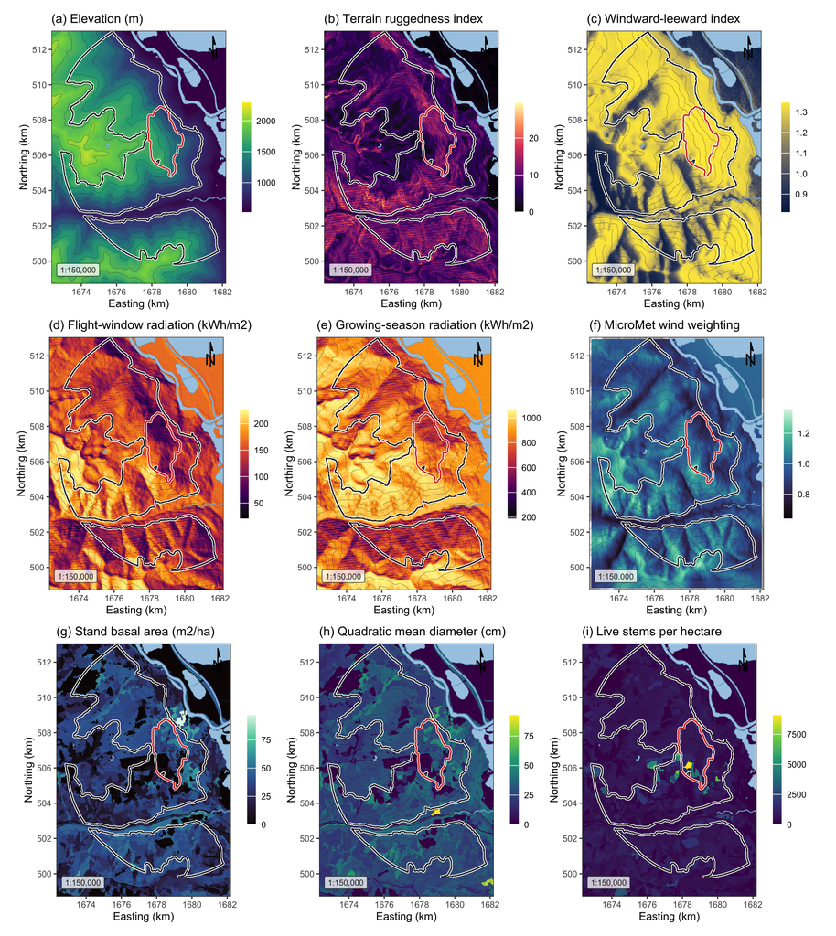

Figure 1: Landscape, terrain and stand surfaces across the study area, all EPSG:3153 at 30 m over Esri World Shaded Relief. (a) elevation; (b) terrain ruggedness index; (c) windward-leeward index at the prevailing bearing; (d) flight-window direct radiation; (e) growing-season direct radiation; (f) the MicroMet wind weighting factor at the prevailing bearing; (g) stand basal area; (h) quadratic mean diameter; (i) live stems per hectare. The white outline marked the study perimeter and the red outline the 2015 Mt Midgeley burn, with contours at 200 m.

```r
geo   <- rast(file.path(SA, "geomorphometry_context.tif"))
vri   <- rast(file.path(SA, "vri_context.tif"))
elevc <- rast(file.path(SA, "dem_context.tif"))
mmb   <- rast(file.path(SA, "micromet_weight_context.tif"))
ctx   <- map_context(per, burn, SA)
m <- function(r, title, pal = "viridis") academic_map(r, title, ctx, pal, base_size = 7)
(m(elevc, "(a) Elevation (m)") | m(geo[["tri"]], "(b) Terrain ruggedness index", "magma") | m(geo[["wind_effect"]], "(c) Windward-leeward index", "cividis")) /
(m(geo[["solar_flight_direct"]], "(d) Flight-window radiation (kWh/m2)", "inferno") | m(geo[["solar_season_direct"]], "(e) Growing-season radiation (kWh/m2)", "inferno") | m(mmb, "(f) MicroMet wind weighting", "mako")) /
(m(vri[["BASAL_AREA"]], "(g) Stand basal area (m2/ha)", "mako") | m(vri[["QUAD_DIAM_125"]], "(h) Quadratic mean diameter (cm)", "viridis") | m(vri[["VRI_LIVE_STEMS_PER_HA"]], "(i) Live stems per hectare", "viridis"))
```

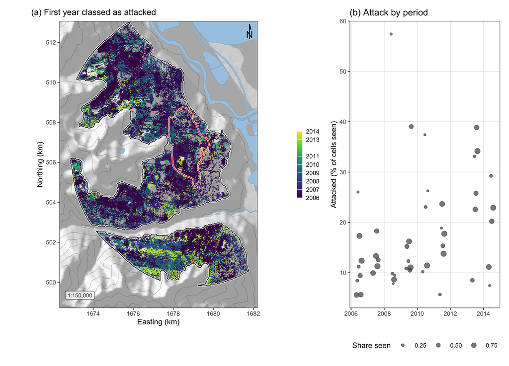

Figure 2: Red-stage attack across the study perimeter. (a) The first year in which each cell was classed as attacked in any sixteen-day period, over shaded relief with the perimeter in white and the 2015 Mt Midgeley burn in red. The panel combines periods for display only, and every model used each period separately. (b) The share of the cells seen in each period that were classed as attacked, one point per period.

```r
maps <- lapply(seq_len(nrow(EP)), function(i) rast(file.path(BC, "epoch-redstage", sprintf("redstage_%d_e%02d.tif", EP$year[i], EP$epoch[i]))))
yrs <- sort(unique(EP$year))
ever <- rast(lapply(yrs, function(y) max(rast(maps[EP$year == y]), na.rm = TRUE)))
first <- mask(app(ever, function(v) { i <- which(v == 1)[1]; if (is.na(i)) NA_real_ else yrs[i] }), msk)
pa <- academic_map(first, "(a) First year classed as attacked", map_context(per, burn, SA), "viridis", base_size = 8) +
  scale_fill_viridis_c(breaks = yrs, labels = yrs, na.value = "transparent", name = NULL)
pb <- ggplot(EP, aes(as.Date(start), 100 * prevalence)) + geom_point(aes(size = valid_cells / N_CELL), colour = "grey30", alpha = 0.7) +
  scale_size_area(max_size = 2.5, name = "Share seen") + labs(x = NULL, y = "Attacked (% of cells seen)", title = "(b) Attack by period") +
  theme_bw(base_size = 8) + theme(panel.grid.minor = element_blank(), legend.position = "bottom")
pa + pb + plot_layout(widths = c(2.2, 1.3))
```

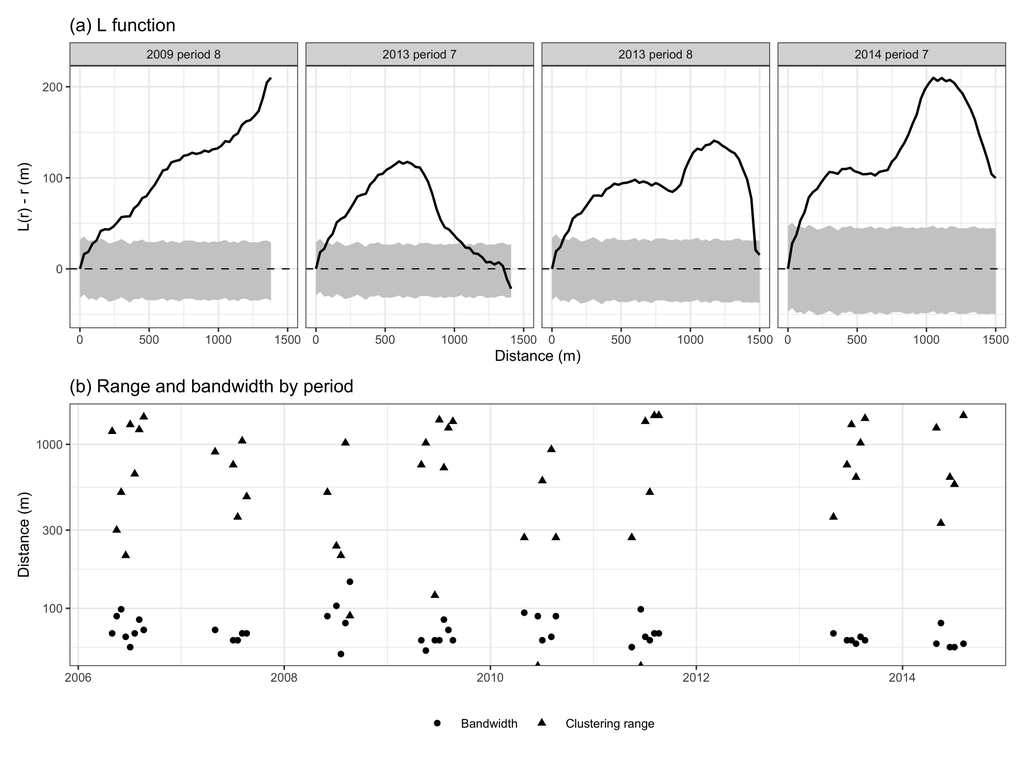

Figure 3: Clustering of red-stage attack. (a) The L function, as L(r) - r, in the four periods with the most attacked cells, against the global envelope of 999 random relabellings of the cells seen in that period, the grey band. (b) The clustering range, the largest distance at which the observed L function lay above the envelope, and the likelihood cross-validated bandwidth in every period.

```r
env <- read.csv(file.path(MD, "l_envelopes.csv"))
top <- head(PP$map[order(-PP$cells_attacked)], 4)
e4 <- env[env$map %in% top, ]; e4$lab <- sub("redstage_(\\d{4})_e0?(\\d+)\\.tif", "\\1 period \\2", e4$map)
pa <- ggplot(e4, aes(r)) + geom_ribbon(aes(ymin = L_lo - r, ymax = L_hi - r), fill = "grey80") + geom_hline(yintercept = 0, linetype = 2, linewidth = 0.3) +
  geom_line(aes(y = L_obs - r), linewidth = 0.6) + facet_wrap(~lab, nrow = 1) + labs(x = "Distance (m)", y = "L(r) - r (m)", title = "(a) L function") +
  theme_bw(base_size = 8)
pb <- PP |> transmute(start = as.Date(sprintf("%d-05-01", year)) + (epoch - 1) * 16, `Clustering range` = cluster_range_m, `Bandwidth` = bw_ppl) |>
  pivot_longer(-start) |> ggplot(aes(start, value, shape = name)) + geom_point(size = 1.4) + scale_y_log10() +
  labs(x = NULL, y = "Distance (m)", shape = NULL, title = "(b) Range and bandwidth by period") + theme_bw(base_size = 8) + theme(legend.position = "bottom")
pa / pb
```

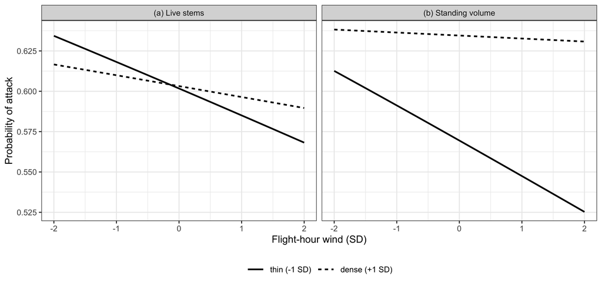

Figure 4: Predicted probability of attack against flight-hour wind, in standard deviations, at one standard deviation below and above the mean of (a) live stems and (b) standing volume, with every other term at its mean and the period effect at the most sampled period. The model was fitted on equal numbers of attacked and unattacked cells in each period, so the level of the curves is not the landscape probability and only their slopes are read. Plume disruption predicts the lowest attack in thin, windy stands.

```r
cv <- read.csv(file.path(MD, "interaction_curves.csv"))
cv <- cv[cv$set == "density by wind" & cv$other == "ep_wind_flight", ]
cv$Density <- factor(ifelse(cv$at < 0, "thin (-1 SD)", "dense (+1 SD)"), levels = c("thin (-1 SD)", "dense (+1 SD)"))
cv$panel <- ifelse(cv$density == "VRI_LIVE_STEMS_PER_HA", "(a) Live stems", "(b) Standing volume")
ggplot(cv, aes(x, p_attack, linetype = Density)) + geom_line(linewidth = 0.7) + facet_wrap(~panel) +
  labs(x = "Flight-hour wind (SD)", y = "Probability of attack", linetype = NULL) + theme_bw(base_size = 9) + theme(legend.position = "bottom")
```

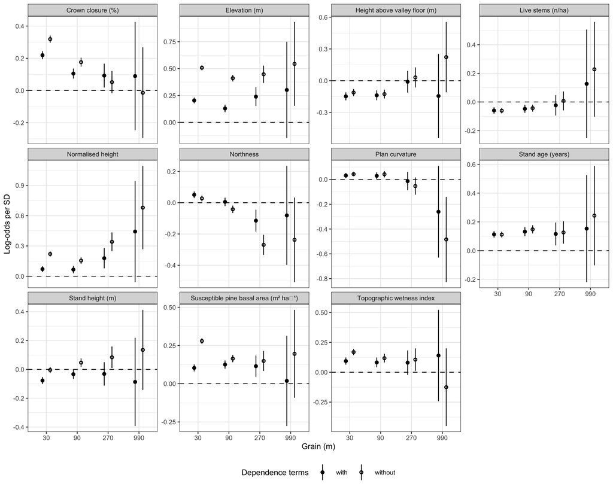

Figure 5: The final model’s environmental coefficients refitted at four grains, with their 95 per cent confidence intervals, without the dependence terms (open circles) and with them rebuilt at each grain (filled circles).

```r
GRT |> mutate(label = pretty_terms(term), lo = estimate - 1.96 * se, hi = estimate + 1.96 * se, Dependence = ifelse(dependence, "with", "without")) |>
  ggplot(aes(factor(grain_m), estimate, shape = Dependence)) + geom_hline(yintercept = 0, linetype = 2, linewidth = 0.3) +
  geom_pointrange(aes(ymin = lo, ymax = hi), position = position_dodge(width = 0.5), size = 0.2) + scale_shape_manual(values = c(with = 19, without = 1)) +
  facet_wrap(~label, scales = "free_y", ncol = 4) + labs(x = "Grain (m)", y = "Log-odds per SD", shape = "Dependence terms") +
  theme_bw(base_size = 7) + theme(legend.position = "bottom")
```

```r
data.frame(Dataset = c("Red-stage attack", "Stand structure", "Terrain", "Station wind", "Terrain-resolved wind", "Model table"),
           Source = c("Landsat 5 and 8 Collection 2 Level-2", "Vegetation Resources Inventory, annual releases", "Natural Resources Canada High Resolution Digital Elevation Model",
                      "Environment and Climate Change Canada hourly stations", "MicroMet terrain adjustment of station wind", "Rows joined from the above"),
           Spatial = c("30 m", "30 m, rasterised", "30 m", paste(max(EW$stations), "stations within 150 km"), "30 m", "30 m"),
           Temporal = c("16 days", "1 year", "static", "1 hour", "16 days", "16 days"),
           Extent = c(paste(N_EP, "periods"), paste(length(unique(VSRC$vri_year)), "snapshots"), paste(fmt(N_CELL), "cells"),
                      paste(fmt(sum(EW$hours_all)), "hours"), paste(N_EP, "periods"), paste(fmt(nrow(readRDS(file.path(MD, "epoch_model_table.rds")))), "cell-periods"))) |>
  save_tbl("table-S1-inventory")
EP |> left_join(PP, by = c("year", "epoch")) |>
  transmute(Year = year, Period = epoch, Start = start, `Cells seen` = fmt(valid_cells), `Attacked (%)` = sprintf("%.1f", 100 * prevalence),
            `Clark-Evans R` = sprintf("%.3f", clark_evans_R), `NN ratio` = sprintf("%.3f", nn_ratio), `Range (m)` = cluster_range_m, `Bandwidth (m)` = sprintf("%.0f", bw_ppl)) |>
  save_tbl("table-S2-periods")
ONE |> transmute(Variable = pretty_terms(variable), `LR chi-square` = sprintf("%.2f", lr_chisq), Estimate = paste0(sprintf("%+.3f", estimate), stars(lr_p)),
                 SE = sprintf("%.3f", se), `Within-period SD share` = sprintf("%.2f", within_epoch_sd_share)) |>
  save_tbl("table-S3-single-variables")
SCR |> transmute(Candidate = pretty_terms(candidate), `Elastic net, lambda min` = ifelse(elastic_net_lambda_min, "kept", ""),
                 `Elastic net, lambda 1SE` = ifelse(elastic_net_lambda_1se, "kept", ""), `Final model` = ifelse(in_final, "kept", "")) |>
  save_tbl("table-S4-screen")
saveRDS(list(mm_ww = range(as.vector(minmax(rast(file.path(BC, "covariates/micromet-context/wind_weight_by_direction.tif"))))),
             eta = sub(".*cells, ", "", readLines(file.path(BC, "covariates/micromet-context/curvature_length_scale.txt")))),
        file.path(TBLDIR, "si-values.rds"))
```

```r
.pngdir <- c(here::here("01.manuscript/Manuscript_files/figure-docx"), here::here(".quarto/_freeze/01.manuscript/Manuscript/figure-docx"))
.out <- here::here("03.outputs/PNG"); dir.create(.out, recursive = TRUE, showWarnings = FALSE)
for (.d in .pngdir) if (dir.exists(.d)) file.copy(list.files(.d, "\\.png$", full.names = TRUE), .out, overwrite = TRUE)
.order <- c("fig-study-area-1.png", "fig-spread-1.png", "fig-clustering-1.png", "fig-interaction-1.png", "fig-grain-1.png")
for (.i in seq_along(.order)) if (file.exists(file.path(.out, .order[.i])))
  file.copy(file.path(.out, .order[.i]), here::here("01.manuscript", sprintf("Fig%d.png", .i)), overwrite = TRUE)
if (file.exists(file.path(.out, "fig-flight-window-1.png"))) file.copy(file.path(.out, "fig-flight-window-1.png"), file.path(.out, "FigS1.png"), overwrite = TRUE)
```

```r
if (PENDING) stop("Results were read before the chunks that write them had run. Render the manuscript a second time so the Abstract and Results read the finished files.")
```